# Shor's Algorithm

Shor's algorithm is a quantum algorithm for finding the prime factors of an odd composite integer $N$. The algorithm was developed by Peter Williston Shor and first published in the 35th Annual Symposium on Foundations of Computer Science in 1994 under the title [*Algorithms for quantum computation: Discrete logarithms and factoring*](https://ieeexplore.ieee.org/document/365700).

Despite being one of the earliest quantum algorithms, Shor's algorithm remains one of the most celebrated and impactful results in quantum computing. Its importance comes from the fact that it gives a polynomial-time quantum algorithm for a problem for which no polynomial-time classical algorithm is known. This has strong implications for public-key cryptography, especially RSA (Rivest-Shamir-Adleman), whose security relies on the difficulty of factoring large composite integers. In principle, a sufficiently large fault-tolerant quantum computer running Shor's algorithm could break RSA and related cryptographic systems. In practice, today's quantum computers are not yet large or reliable enough to deploy Shor's algorithm at cryptographically relevant scales, although progress in quantum hardware brings this idea closer to reality.

In response to this long-term shift in the security landscape, researchers and cryptographers have developed cryptographic protocols intended to remain secure even against quantum computers, giving rise to the field of post-quantum cryptography. The National Institute of Standards and Technology (NIST), a U.S. federal agency within the Department of Commerce, [launched its post-quantum cryptography standardization project in 2016](https://web.archive.org/web/20260507233444/https://nvlpubs.nist.gov/nistpubs/ir/2016/NIST.IR.8105.pdf). In 2024, [NIST released its first three finalized post-quantum cryptography standards](https://web.archive.org/web/20260519224902/https://www.nist.gov/news-events/news/2024/08/nist-releases-first-3-finalized-post-quantum-encryption-standards). Shor's algorithm does not mean that all cryptographic protocols are insecure against quantum computers, but it does show that security against classical attacks alone is not sufficient. As such, post-quantum candidates should be evaluated against both classical and quantum attacks.

In this tutorial, we will study Shor's algorithm. We will begin with a high-level overview of the algorithm, then examine its mathematical details and implementation. Since Shor's algorithm is probabilistic, we will also consider a heuristic analysis of the ways a run of the algorithm may fail, and how repeated iterations increase the probability of success. We will then discuss the complexity of Shor's algorithm, resource estimates for running it on quantum hardware, hardware demonstrations of Shor's algorithm, and other quantum approaches to factoring integers. We will also compare integer factorization in the classical and quantum settings, including what Shor's algorithm implies for complexity classes, what is known as a theoretical result, and what remains a plausible but unproven conjecture. Finally, we will implement a small instance of Shor's algorithm in Qiskit by factoring $15$.

It is worth noting that Shor's result appears in four versions, including the [original 1994 conference paper in the 35th Annual Symposium on Foundations of Computer Science](https://ieeexplore.ieee.org/document/365700), the two [arXiv preprint versions](https://arxiv.org/abs/quant-ph/9508027) submitted in August 1995 and January 1996, and the [1997 journal article in *SIAM Journal on Computing*](https://epubs.siam.org/doi/10.1137/S0097539795293172). In this tutorial, any reference to Shor's paper refers to the latest 1996 arXiv version unless explicitly stated otherwise. In the appendix, there is a section on the timeline of the development of Shor's algorithm, which briefly discusses some of the overall changes across these versions.

1. Overview of Shor's Algorithm
2. Connecting the Steps of Shor's Algorithm
3. The Quantum Order-Finding Subroutine
4. Classical Post-Processing
5. Probability of Success in Shor's Algorithm
6. Gate Complexity of Shor's Algorithm
7. Resource Estimates for Shor's Algorithm
8. Quantum Factoring Demonstrations
9. Classical and Quantum Complexity of Integer Factorization and Its Implications
10. Implementation of Shor's Algorithm
11. Conclusion

### Appendix

12. Appendix 1: Number Theory Background
13. Appendix 2: Timeline of the Development of Shor's Algorithm
14. Appendix 3: Biography
15. Appendix 4: References and Suggested Readings

### Overview of Shor's Algorithm

Shor's algorithm is not a purely quantum algorithm in the sense that it includes classical preprocessing and post-processing steps. The quantum subroutine, order finding via the quantum Fourier transform, is what provides the speedup over classical approaches. This subroutine exploits the periodic structure of modular exponentiation, which is an instance of the hidden subgroup problem (HSP) over the integers. HSP is a natural fit for quantum computation because quantum Fourier transforms are inherently good at detecting hidden periodicities in group structures. Since the algorithm ultimately solves an integer factorization problem, some familiarity with elementary number theory, such as modular arithmetic and continued fractions, is helpful for better understanding how the algorithm works. Appendix 1 includes a brief summary of the relevant concepts: modular arithmetic, gcd, coprimality, the multiplicative group $\mathbb{Z}_N^*$, Euler's totient function, order of an element, and continued fractions.

We also note that, for the purposes of this tutorial, we use a formulation of Shor's algorithm suited to the exposition here. This formulation can be adjusted. For example, in this version, step 5 instructs the algorithm to repeat from step 3 if no successful convergent is found. In practice, there are alternative post-processing methods that can reduce the need for such repetitions. We will discuss those later.

While Shor's algorithm is capable of factoring any odd composite number, in this tutorial we will restrict our focus to odd composites that are the product of two distinct odd primes, $N = p \times q$. For example, $15 = 3 \times 5$ and $21 = 3 \times 7$ are of this form, but $25 = 5 \times 5$ and $105 = 3 \times 5 \times 7$ are not.

Let $N$ be such an integer. Then Shor's algorithm works as follows:

1. Choose an integer $t$ such that $N^2 \leq 2^t < 2N^2$.
2. Choose a random $x \in \mathbb{Z}_N^*$.
3. Use quantum phase estimation on modular exponentiation by $x$.
4. Measure the phase register to obtain an integer $0 \leq j < 2^t$.
5. Use continued fractions to compute convergents of $j/2^t$. Among the convergents $s/r$, call a convergent successful if its denominator satisfies $r<N$, and $x^r \equiv 1 \pmod N$. If a successful convergent is found, proceed to step 6 with this value of $r$. If no successful convergent is found, repeat from step 3.
6. If $r$ is even and $x^{r/2} \not\equiv -1 \pmod{N}$, compute $\gcd(x^{r/2}-1, N)$ and $\gcd(x^{r/2}+1, N)$. Otherwise, repeat from step 2.

### Connecting the Steps of Shor's Algorithm

Before going into the mathematical details of the quantum order-finding subroutine, we first clarify how the surrounding classical pieces fit together. In this section, we discuss the preprocessing steps 1 and 2, explain at a high level what information the quantum subroutine produces, describe how that information is used by the continued-fraction step 5, and show why the gcd computations in step 6 can produce factors of $N$. The probability arguments for steps 1 and 2 are relatively direct, so we include them here. The probability analysis for step 5 and step 6 depends more directly on the behaviour of the quantum order-finding subroutine and on arithmetic properties of the recovered order, so we postpone that discussion until after the quantum subroutine has been described.

In the first step, the algorithm requires choosing an integer $t$ such that $N^2 \leq 2^t < 2N^2$. One needs to first ensure such a $t$ even exists. Indeed, for any integer $A > 0$ and integer $n \geq 2$, there exists an integer $t$ such that $A \leq n^t < nA$. To see this, note that the interval $[\log_n A,\; \log_n A + 1)$ has length 1 and therefore contains at least one integer; take $t = \lceil \log_n A \rceil$. Then $\log_n A \leq t < \log_n A + 1$, and exponentiating with base $n$ gives $A \leq n^t < nA$.

Therefore, letting $A = N^2$ and $n = 2$ as a special case yields the desired result: there exists an integer $t$ such that $N^2 \leq 2^t < 2N^2$.

Step 2 of the algorithm requires choosing a random $x \in \mathbb{Z}^*_N$. To do so, one can simply pick an integer uniformly from the set $\{1, \dots, N-1\}$ and check that $\gcd(x, N) = 1$. If $\gcd(x, N) \neq 1$, then a non-trivial factor has been found and it is no longer necessary to proceed with the remaining steps. However, in practice, the probability of landing on such a case is negligible.

To see why, note that $N = p \times q$, so $\varphi(N) = (p-1)(q-1) = \underbrace{pq}_{=N} - p - q + 1$. Hence there are $N - p - q + 1$ integers in $\{1, \dots, N-1\}$ that are coprime to $N$, and the number of integers that are not coprime to $N$ is $(N-1) - (N - p - q + 1) = p + q - 2$. These are the multiples of $p$, namely $\{p, 2p, \dots, (q-1)p\}$, and the multiples of $q$, namely $\{q, 2q, \dots, (p-1)q\}$. Therefore, the probability of landing on a non-coprime element is

$$ \frac{p+q-2}{N-1} \approx \frac{2\sqrt{N} - 2}{N-1} \approx \frac{2\sqrt{N}}{N} = \frac{2}{\sqrt{N}}, $$

where we approximate $p \approx q \approx \sqrt{N}$ as is typical for RSA-type numbers. For large $N$, this is negligibly small.

Additionally, $x = 1$ and $x = N-1$, while coprime to $N$, can be ruled out as useful choices. The element $x = 1$ has order 1, which is odd, so step 6 always fails. The element $x = N-1 \equiv -1 \pmod{N}$ has order 2, but $x^{r/2} = x^1 = N-1 \equiv -1 \pmod{N}$, so the other condition in step 6 fails. In practice, one can simply sample uniformly from $\{2, \dots, N-2\}$ to avoid these edge cases, though the probability of hitting them is already negligible.

The quantum subroutine uses phase estimation to detect the period of the modular exponentiation function

$$ f(a)=x^a \bmod N. $$

If $r=\operatorname{ord}_N(x)$, then $f$ has period $r$, since

$$ x^{a+r}\equiv x^a \pmod N. $$

After phase estimation, measuring the phase register gives an integer $0\le j<2^t$. The measurement distribution is concentrated near values for which

$$ \frac{j}{2^t}\approx \frac{s}{r} $$

for some integer $s\in\{0,\dots,r-1\}$.

Thus the measurement does not usually give $r$ directly. Instead, it gives a rational approximation whose denominator contains information about the order. The continued-fraction step extracts candidate denominators from $j/2^t$, and these candidates are then checked classically by testing whether

$$ x^r\equiv 1 \pmod N. $$

In the formulation of Shor's algorithm used in this tutorial, step 5 requires a candidate $r$ satisfying $x^r \equiv 1 \pmod N$. In this case, if no such candidate is obtained from the continued-fraction step, we repeat from step 3. Other formulations may use additional post-processing strategies, such as combining several candidates or testing small multiples, and we will discuss these alternatives later.

Assume now that step 5 has produced the order $r=\operatorname{ord}_N(x)$. In step 6, we check whether $r$ is even and whether $x^{r/2}\not\equiv -1 \pmod N$. Since $r$ is the order of $x$, its minimality also implies

$$ x^{r/2}\not\equiv 1 \pmod N, $$

because otherwise $r/2$ would already be a positive exponent satisfying $x^{r/2}\equiv 1 \pmod N$. Therefore, when the conditions checked in step 6 are satisfied, namely $r$ is even and $x^{r/2}\not\equiv -1 \pmod N$, we have

$$ x^{r/2}\not\equiv \pm 1 \pmod N. $$

Since $x^r\equiv 1 \pmod N$, we have

$$ x^r-1\equiv 0 \pmod N. $$

For even $r$,

$$ x^r-1 = \left(x^{r/2}-1\right)\left(x^{r/2}+1\right). $$

Hence,

$$ \left(x^{r/2}-1\right)\left(x^{r/2}+1\right) \equiv 0 \pmod N. $$

Equivalently, $N$ divides the product $\left(x^{r/2}-1\right)\left(x^{r/2}+1\right)$. However, because

$$ x^{r/2}\not\equiv \pm 1 \pmod N $$

the divisibility by $N$ must come from nontrivial common factors between $N$ and the two terms. The Euclidean algorithm extracts these common factors by computing

$$ \gcd(x^{r/2}-1,N),\qquad \gcd(x^{r/2}+1,N). $$

These gcds yield nontrivial proper factors of $N$.

For Shor's algorithm to be efficient, besides polynomial runtime, the algorithm also requires a sufficiently high success probability. Shor's algorithm is not deterministic. It is a bounded-error quantum algorithm: individual runs may fail to produce the factors of $N$, but the probability of success can be amplified by repetition.

We will return to the probability analysis after describing the quantum order-finding subroutine. At that point, we will look into the success probabilities associated with the continued-fraction step, the conditions in step 6, and the role of repetition and classical post-processing in increasing the overall probability of success.

### The Quantum Order-Finding Subroutine

After steps 1 and 2, we have identified an integer $t$ such that $N^2 \leq 2^t < 2N^2$ and a choice of $x\in\mathbb{Z}_N^*$. The goal of the quantum subroutine is to find the order of $x$ modulo $N$, namely the smallest integer $r$ such that $$ x^{r} \equiv 1 \pmod N $$

Equivalently, we want to find the period of the modular exponentiation function

$$ f(j)=x^j \bmod N. $$

Indeed, if $r=\operatorname{ord}_N(x)$, then

$$ f(j+r)=x^{j+r}\equiv x^j x^r \equiv x^j \pmod N, $$

so $f$ is periodic with period $r$.

The quantum subroutine consists of two main registers. The first register, which we will call the phase register, has $t$ qubits and can represent the integers $0,\dots,2^t-1$. Before the quantum Fourier transform, these basis states are used to index the exponents in the modular exponentiation function $x^j \bmod N$. After the inverse QFT, the same register is interpreted as storing a phase or frequency estimate, whose measured value $j$ satisfies $j/2^t \approx s/r$ in successful runs.

The second register, which we call the modular exponentiation register, has $n=\lceil \log_2 N\rceil$ qubits and stores the values $x^j\bmod N$ produced by the modular exponentiation step.

The quantum subroutine uses three main ingredients:

1. **Superposition:** the phase register is placed in a uniform superposition over indices $j=0,\dots,2^t-1$.
2. **Modular exponentiation:** the modular exponentiation register is used to store $x^j \bmod N$, creating a quantum state that contains the periodic structure of $f(j)=x^j\bmod N$.
3. **Quantum Fourier transform:** applying the inverse QFT to the phase register converts the hidden periodicity into peaks near integer values proportional to $2^t/r$.

The quantum subroutine begins with the state $|\psi_0\rangle$ initialized as the all-zero state

$$ |\psi_0\rangle = |\underbrace{0\dots 0}_{t}\rangle |\underbrace{0\dots 0}_{n}\rangle. $$

We then create a uniform superposition over the phase register:

$$ \begin{aligned} |\psi_1\rangle &= \left(H^{\otimes t}\otimes I^{\otimes n}\right)|\psi_0\rangle \\ &= \frac{1}{\sqrt{2^t}} \sum_{a=0}^{2^t-1} |a\rangle |0\rangle^{\otimes n}. \end{aligned} $$

At the next step, we apply modular exponentiation. For the purposes of this tutorial, we treat quantum modular exponentiation as an abstract unitary without delving too deeply into its gate-level implementation. The objective of this step is to compute the modular exponentiation function

$$ a \mapsto x^a \bmod N. $$

Classically, modular exponentiation is relatively straightforward and efficient. Using repeated squaring, one computes the powers

$$ x^{2^0}, x^{2^1}, x^{2^2}, \dots \pmod N $$

and multiplies the selected powers according to the binary expansion of $a$. With standard arithmetic, this gives a polynomial-time implementation, commonly quoted as $\mathcal{O}(n^3)$ when $n=\lceil \log_2 N\rceil$. See Section 3 of Shor's paper.

On a quantum computer, however, this computation must be implemented reversibly as a unitary operation. Classical computations can overwrite registers, discard intermediate values, and use irreversible gates. Quantum circuits cannot do this. Instead, modular exponentiation must be built from reversible arithmetic, such as reversible modular addition and controlled modular multiplication, with temporary workspace uncomputed at the end.

One of the earliest treatments of quantum modular exponentiation was given in [*Quantum Networks for Elementary Arithmetic Operations*](https://arxiv.org/abs/quant-ph/9511018) by Vedral, Barenco, and Ekert. More recent developments include Craig Gidney's [*Halving the cost of quantum addition*](https://quantum-journal.org/papers/q-2018-06-18-74/) and the survey [*A Comprehensive Study of Quantum Arithmetic Circuits*](https://arxiv.org/abs/2406.03867) by Wang et al. With standard reversible arithmetic, modular exponentiation is commonly quoted as having gate complexity $\mathcal{O}(n^3)$. The exact number of gates, depth, and ancilla qubits depends on the particular modular exponentiation circuit used.

We let $U_{x,N}$ denote the modular exponentiation unitary. The subscripts indicate that the operation depends on both the chosen base $x$ and the modulus $N$. In this tutorial, $N$ is fixed, but we keep it in the notation to make this dependence explicit. One reversible version is defined by its action on basis states as

$$ U_{x,N}|a\rangle|k\rangle = |a\rangle |k+x^a \bmod N\rangle, $$

where the addition in the second register is taken modulo $N$. For each fixed value of $a$, the quantity $x^a \bmod N$ is a fixed shift applied to the second register. The transformation

$$ k \mapsto k+x^a \bmod N $$

can be undone by subtracting the same quantity modulo $N$. Thus the operation is reversible.

In the algorithm, the second register is initialized to $|0\rangle$. Therefore,

$$ U_{x,N}|a\rangle|0\rangle = |a\rangle |x^a \bmod N\rangle. $$

Applying this unitary to $|\psi_1\rangle$ gives

$$ \begin{aligned} |\psi_2\rangle &= U_{x,N}|\psi_1\rangle \\ &= \frac{1}{\sqrt{2^t}} \sum_{a=0}^{2^t-1} |a\rangle |x^a \bmod N\rangle. \end{aligned} $$

The state $|\psi_2\rangle$ contains the periodic structure we want to extract. The phase register contains each integer $a\in\{0,1,\dots,2^t-1\}$, while the modular exponentiation register contains the corresponding value $x^a\bmod N$:

$$ |\psi_2\rangle = \frac{1}{\sqrt{2^t}} \sum_{a=0}^{2^t-1} |a\rangle |x^a\bmod N\rangle. $$

Since $r=\operatorname{ord}_N(x)$, we have

$$ x^{a+r}\equiv x^a \pmod N. $$

Thus the modular exponentiation values repeat every $r$ steps. To describe the endpoint of the ascending-order expansion, write

$$ 2^t-1=Qr+\ell,\qquad 0\le \ell<r. $$

Then

$$ x^{2^t-1}=x^{Qr+\ell}\equiv x^\ell \pmod N, $$

so the final term is

$$ |2^t-1\rangle |x^{2^t-1}\bmod N\rangle = |Qr+\ell\rangle |x^\ell\bmod N\rangle. $$

The endpoint therefore belongs to the same repeated-value group as the terms whose phase-register values are congruent to $\ell$ modulo $r$. Written in ascending order, the state has the pattern

$$ \begin{aligned} |\psi_2\rangle = \frac{1}{\sqrt{2^t}}\Big(& {\color{red}|0\rangle|1\rangle} + {\color{blue}|1\rangle|x\bmod N\rangle} + {\color{green}|2\rangle|x^2\bmod N\rangle} +\cdots+ {\color{orange}|\ell\rangle|x^\ell\bmod N\rangle} +\cdots+ {\color{purple}|r-1\rangle|x^{r-1}\bmod N\rangle} \\ &+ {\color{red}|r\rangle|1\rangle} + {\color{blue}|r+1\rangle|x\bmod N\rangle} + {\color{green}|r+2\rangle|x^2\bmod N\rangle} +\cdots+ {\color{orange}|r+\ell\rangle|x^\ell\bmod N\rangle} +\cdots+ {\color{purple}|2r-1\rangle|x^{r-1}\bmod N\rangle} \\ &+\cdots \\ &+ {\color{red}|Qr\rangle|1\rangle} + {\color{blue}|Qr+1\rangle|x\bmod N\rangle} + {\color{green}|Qr+2\rangle|x^2\bmod N\rangle} +\cdots+ {\color{orange}|Qr+\ell\rangle|x^\ell\bmod N\rangle} \Big). \end{aligned} $$

The final block of consecutive phase-register indices need not contain the same number of terms as the previous blocks. It stops at $Qr+\ell=2^t-1$. If $\ell=r-1$, then this last block contains all remainders $0,1,\dots,r-1$. If $\ell<r-1$, it contains only the remainders $0,1,\dots,\ell$.

In the special case where $r$ divides $2^t$, we have

$$ 2^t-1=\left(\frac{2^t}{r}-1\right)r+(r-1), $$

so $\ell=r-1$, and every block of consecutive indices has the same length $r$. In particular, if $r$ is a power of $2$, then $r$ divides $2^t$. In general, $r$ need not divide $2^t$, so the last block of consecutive indices may contain fewer than $r$ terms.

If $\ell$ equals one of the explicitly displayed remainders, such as $0$, $1$, $2$, or $r-1$, then the endpoint group coincides with that group.

To make the periodic structure explicit, we regroup terms according to their remainder modulo $r$. Every exponent $a$ has a unique decomposition

$$ a=qr+b, $$

where

$$ b\in\{0,1,\dots,r-1\} $$

and

$$ q\ge 0. $$

For such a term,

$$ x^a=x^{qr+b}=x^b(x^r)^q\equiv x^b \pmod N. $$

For a fixed remainder $b$, the allowed values of $q$ are exactly those satisfying

$$ qr+b\le 2^t-1. $$

Solving for $q$ gives

$$ q\le \frac{2^t-1-b}{r}. $$

Since $q$ must be an integer, the largest allowed value is

$$ q_{\max}(b)=\left\lfloor \frac{2^t-1-b}{r}\right\rfloor. $$

Therefore the number of terms in the group with remainder $b$ is

$$ A_b=q_{\max}(b)+1 = \left\lfloor \frac{2^t-1-b}{r}\right\rfloor+1, $$

where the $+1$ accounts for the value $q=0$.

In grouped form, this looks like

$$ \begin{aligned} |\psi_2\rangle = \frac{1}{\sqrt{2^t}}\Big(& {\color{red}|0\rangle|1\rangle +|r\rangle|1\rangle +|2r\rangle|1\rangle +\cdots +|(A_0-1)r\rangle|1\rangle} \\ &+ {\color{blue}|1\rangle|x\bmod N\rangle +|r+1\rangle|x\bmod N\rangle +|2r+1\rangle|x\bmod N\rangle +\cdots +|(A_1-1)r+1\rangle|x\bmod N\rangle} \\ &+ {\color{green}|2\rangle|x^2\bmod N\rangle +|r+2\rangle|x^2\bmod N\rangle +|2r+2\rangle|x^2\bmod N\rangle +\cdots +|(A_2-1)r+2\rangle|x^2\bmod N\rangle} \\ &+\cdots \\ &+ {\color{orange}|\ell\rangle|x^\ell\bmod N\rangle +|r+\ell\rangle|x^\ell\bmod N\rangle +|2r+\ell\rangle|x^\ell\bmod N\rangle +\cdots +|(A_\ell-1)r+\ell\rangle|x^\ell\bmod N\rangle} \\ &+\cdots \\ &+ {\color{purple}|r-1\rangle|x^{r-1}\bmod N\rangle +|2r-1\rangle|x^{r-1}\bmod N\rangle +|3r-1\rangle|x^{r-1}\bmod N\rangle +\cdots +|(A_{r-1}-1)r+(r-1)\rangle|x^{r-1}\bmod N\rangle} \Big). \end{aligned} $$

Each group corresponds to one repeated value in the modular exponentiation register. The phase-register values within each group are separated by the period $r$. The endpoint term $|Qr+\ell\rangle|x^\ell\bmod N\rangle$ is the last term of the $\ell$-group, since $Q=A_\ell-1$.

Thus, in the general case,

$$ |\psi_2\rangle = \frac{1}{\sqrt{2^t}} \sum_{b=0}^{r-1} \sum_{q=0}^{A_b-1} |qr+b\rangle |x^b\bmod N\rangle. $$

This notation does not assume that every group has the same length. The value $A_b$ depends on $b$, so different remainder classes may stop at different points before the cutoff $2^t$.

Although $|\psi_2\rangle$ contains the period information we want, this information is still encoded in a quantum state and is not directly accessible to an observer. At this point, one can measure the second register, the modular exponentiation register.

Since $r=\operatorname{ord}_N(x)$, the values

$$ 1,\;x,\;x^2,\;\dots,\;x^{r-1}\pmod N $$

are distinct. Therefore the second register has $r$ possible repeated values, indexed by the remainders $b=0,1,\dots,r-1$.

Suppose the measurement of the second register gives

$$ x^{b_0}\bmod N $$

for some $b_0\in\{0,1,\dots,r-1\}$. The corresponding projection operator is

$$ P_{b_0} = I\otimes |x^{b_0}\bmod N\rangle\langle x^{b_0}\bmod N|. $$

This projector leaves the phase register unchanged and projects the modular exponentiation register onto the measured value. Applying this projector to $|\psi_2\rangle$ and normalizing gives

$$ \begin{aligned} |\psi_3\rangle &= \frac{P_{b_0}|\psi_2\rangle} {\sqrt{\langle \psi_2|P_{b_0}|\psi_2\rangle}} \\ &= \sqrt{\frac{1}{A_{b_0}}} \sum_{q=0}^{A_{b_0}-1} |qr+b_0\rangle |x^{b_0}\bmod N\rangle \\ &= \sqrt{\frac{1}{A_{b_0}}}\Big(|b_0\rangle |x^{b_0}\bmod N\rangle +|r+b_0\rangle |x^{b_0}\bmod N\rangle +|2r+b_0\rangle |x^{b_0}\bmod N\rangle +\cdots +|(A_{b_0}-1)r+b_0\rangle |x^{b_0}\bmod N\rangle \Big). \end{aligned} $$

After this measurement, the second register is fixed at the measured value $|x^{b_0}\bmod N\rangle$. The phase register is left in a superposition of basis states whose indices are separated by the period $r$.

In the special case where $r$ divides $2^t$, each repeated-value group has the same number of terms,

$$ A_{b_0}=\frac{2^t}{r}. $$

Then the normalization factor becomes

$$ \sqrt{\frac{1}{A_{b_0}}} = \sqrt{\frac{r}{2^t}}, $$

and the full two-register state can be written as

$$ |\psi_3\rangle = \sqrt{\frac{r}{2^t}} \sum_{q=0}^{\frac{2^t}{r}-1} |qr+b_0\rangle |x^{b_0}\bmod N\rangle. $$

At this point, the second register is fixed at the measured value $|x^{b_0}\bmod N\rangle$. Therefore, when analyzing the next step, we restrict our attention to the phase register. We write

$$ |\psi_3\rangle_{\mathrm{phase}} = |\psi_3\rangle\big|_{\mathrm{phase}} = \sqrt{\frac{1}{A_{b_0}}} \sum_{q=0}^{A_{b_0}-1} |qr+b_0\rangle, $$

where $|\psi_3\rangle\big|_{\mathrm{phase}}$ means that we suppress the fixed second register and keep only the phase-register state.

If we were to measure $|\psi_3\rangle_{\mathrm{phase}}$ directly, we would obtain one of the indices

$$ qr+b_0, \qquad 0\le q\le A_{b_0}-1. $$

A single such value does not reveal the period $r$. It only gives one element of an arithmetic progression whose spacing is $r$. Moreover, one cannot repeatedly measure the same copy of $|\psi_3\rangle_{\mathrm{phase}}$ to obtain several values from the same progression, because measurement consumes the state. Repeating the whole quantum subroutine also does not guarantee the same value of $b_0$, since each run can project the modular exponentiation register onto a value $|x^{b_0}\bmod N\rangle$ that need not be the same as in previous runs.

Therefore, instead of measuring the phase register directly, we apply the inverse quantum Fourier transform to the phase register. The purpose of this step is to convert the periodic spacing

$$ b_0,\; r+b_0,\; 2r+b_0,\;\dots $$

into a measurement distribution concentrated near indices related to the reciprocal spacing $\frac{1}{r}$.

Applying $\operatorname{QFT}_{2^t}^{\dagger}$ gives

$$ \begin{aligned} |\psi_4\rangle_{\mathrm{phase}} &= \operatorname{QFT}_{2^t}^{\dagger} |\psi_3\rangle_{\mathrm{phase}} \\ &= \sqrt{\frac{1}{A_{b_0}}} \sum_{q=0}^{A_{b_0}-1} \operatorname{QFT}_{2^t}^{\dagger} |qr+b_0\rangle. \end{aligned} $$

Using the convention

$$ \operatorname{QFT}_{2^t}^{\dagger}|a\rangle = \sqrt{\frac{1}{2^t}} \sum_{j=0}^{2^t-1} e^{-\frac{2\pi i aj}{2^t}}|j\rangle, $$

we obtain

$$ \begin{aligned} |\psi_4\rangle_{\mathrm{phase}} &= \sqrt{\frac{1}{A_{b_0}2^t}} \sum_{q=0}^{A_{b_0}-1} \sum_{j=0}^{2^t-1} e^{-\frac{2\pi i(qr+b_0)j}{2^t}} |j\rangle \\ &= \sum_{j=0}^{2^t-1} c_j |j\rangle, \end{aligned} $$

where

$$ c_j = \sqrt{\frac{1}{A_{b_0}2^t}} e^{-\frac{2\pi i b_0j}{2^t}} \sum_{q=0}^{A_{b_0}-1} e^{-\frac{2\pi i qrj}{2^t}}. $$

The factor

$$ e^{-\frac{2\pi i b_0j}{2^t}} $$

has absolute value $1$, so it does not affect the measurement probability. Thus the probability of measuring a particular value $j$ in the phase register is

$$ \Pr(j) = |c_j|^2 = \frac{1}{A_{b_0}2^t} \left| \sum_{q=0}^{A_{b_0}-1} e^{-\frac{2\pi i qrj}{2^t}} \right|^2. $$

This finite geometric sum can be written as

$$ \Pr(j) = \frac{1}{A_{b_0}2^t} \left( \frac{ \sin\left(\frac{\pi A_{b_0} rj}{2^t}\right) }{ \sin\left(\frac{\pi rj}{2^t}\right) } \right)^2, $$

with the usual limiting interpretation when the denominator is $0$.

The expression above shows that the measurement probabilities are governed by a finite Fourier peak. To connect the peak locations to the order $r$, we compare the normalized measurement value $\frac{j}{2^t}$ with rational numbers of the form $\frac{s}{r}$, where

$$ s\in\{0,1,\dots,r-1\}. $$

For any such integer $s$, we can rewrite

$$ \frac{rj}{2^t} = r\left(\frac{j}{2^t}-\frac{s}{r}\right)+s. $$

Since $s$ is an integer, shifting by $s$ inside the exponential does not change the finite geometric sum. Equivalently, define

$$ \Delta_s(j) = \frac{j}{2^t}-\frac{s}{r}. $$

Then

$$ \frac{rj}{2^t}-s = r\Delta_s(j). $$

Therefore the same probability distribution can be written in the centered form

$$ \Pr(j) = \frac{1}{A_{b_0}2^t} \left( \frac{ \sin\left(\pi A_{b_0}r\left(\frac{j}{2^t}-\frac{s}{r}\right)\right) }{ \sin\left(\pi r\left(\frac{j}{2^t}-\frac{s}{r}\right)\right) } \right)^2. $$

This form makes the peak locations explicit. The probability is large when

$$ \frac{j}{2^t}-\frac{s}{r} $$

is close to $0$, meaning

$$ \frac{j}{2^t}\approx \frac{s}{r}. $$

This is similar to finite Fourier peak structure that appears in the QFT analysis in the [QFT tutorial](https://sohrabganjian.github.io/blog/2025/quantum_fourier_transform/).

Thus, after measuring the phase register, we obtain an integer

$$ 0\le j<2^t $$

such that

$$ \frac{j}{2^t}\approx \frac{s}{r} $$

for some integer $s\in\{0,1,\dots,r-1\}$.

The value $j$ is not the period. It is the measurement label of the phase register after the inverse QFT. Its usefulness comes from the fact that the ratio $\frac{j}{2^t}$ approximates a fraction whose denominator is related to the period $r$. This is why the next classical step uses continued fractions.

In the special case where $r$ divides $2^t$, the peaks occur exactly at

$$ j=\frac{s2^t}{r}, \qquad s=0,1,\dots,r-1. $$

In that case,

$$ \frac{j}{2^t} = \frac{s}{r}. $$

If $\gcd(s,r)=1$, then this fraction is already in lowest terms and the denominator is exactly $r$. If $\gcd(s,r)>1$, then reducing $\frac{s}{r}$ gives a denominator that is a proper divisor of $r$.

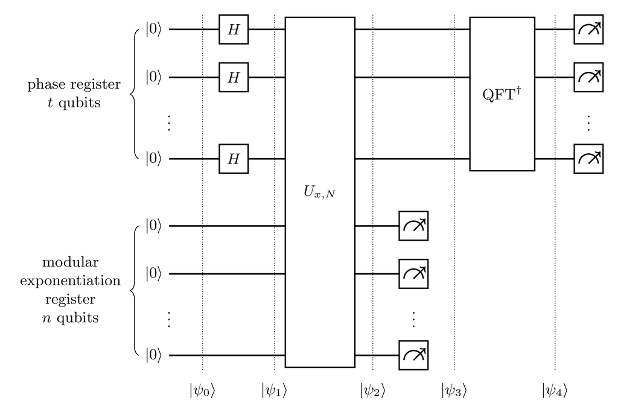

Figure: Quantum order-finding subroutine in Shor's algorithm. The phase register is placed in superposition, modular exponentiation encodes the periodic structure in the modular exponentiation register, the second register is measured, and $\mathrm{QFT}^{\dagger}$ is applied to the phase register before the final measurement.

### Classical Post-Processing

As discussed in the quantum order-finding subroutine, the direct output of the subroutine is the phase-register measurement outcome $j$. The normalized value

$$ \frac{j}{2^t} $$

is interpreted as a phase estimate, and in successful runs it approximates a fraction of the form

$$ \frac{s}{r}, $$

where $r=\operatorname{ord}_N(x)$ is the period we want to recover. The classical post-processing step uses continued fractions to extract candidate denominators from this approximation.

Recall that a real number $\alpha$ can be expanded as a continued fraction

$$ \alpha = a_0+\frac{1}{a_1+\frac{1}{a_2+\frac{1}{a_3+\cdots}}}, $$

where $a_0$ is an integer and $a_1,a_2,a_3,\dots$ are positive integers. Truncating this expansion at different depths gives rational approximations called convergents:

$$ \frac{s_1}{d_1},\frac{s_2}{d_2},\frac{s_3}{d_3},\dots. $$

In Shor's algorithm, we apply this procedure to

$$ \alpha=\frac{j}{2^t}. $$

Since $\frac{j}{2^t}$ is rational, its continued-fraction expansion is finite. Moreover, the number of convergents is the number of Euclidean-algorithm steps needed for $j$ and $2^t$, which is $\mathcal{O}(t)$ in the worst case. Since $t=\mathcal{O}(\log N)$, checking the convergents is efficient.

The algorithm inspects the denominators $d_i$ of the convergents. Since the true order satisfies $r<N$, we only need to consider denominators with

$$ d_i<N. $$

Each such candidate is tested classically by checking whether

$$ x^{d_i}\equiv 1 \pmod N. $$

If one or more denominators pass this test, we choose the smallest such denominator and proceed to step 6 with this value. This choice is consistent with the definition of the order: $\operatorname{ord}_N(x)$ is the smallest positive integer satisfying

$$ x^r\equiv 1\pmod N. $$

If no candidate denominator passes the test, we repeat the quantum subroutine from step 3. If a candidate passes step 5 but fails the conditions in step 6, namely the candidate is odd or $x^{d_i/2}\equiv -1\pmod N$, then we repeat from step 2 with a new choice of $x$.

There are also refinements to this basic procedure. The hidden phase produced by the quantum subroutine has the form

$$ \frac{s}{r}, \qquad s\in\{0,1,\dots,r-1\}, $$

where $r=\operatorname{ord}_N(x)$. If $\gcd(s,r)=1$, then this fraction is already in lowest terms, so the relevant continued-fraction convergent has denominator $r$. In that case, the order can be recovered directly.

If instead $\gcd(s,r)>1$, then the same hidden phase reduces to

$$ \frac{s}{r} = \frac{s'}{d}, $$

where

$$ s'=\frac{s}{\gcd(s,r)}, \qquad d=\frac{r}{\gcd(s,r)}. $$

The continued-fraction algorithm returns the reduced fraction $\frac{s'}{d}$, whose denominator $d$ is a proper divisor of the true order $r$. In that case, $d$ may fail the test

$$ x^d\equiv 1\pmod N. $$

However, this information is not necessarily useless. One can combine denominators obtained from multiple runs, for example by taking least common multiples, or test small multiples of a candidate denominator. These approaches can reduce the number of times the quantum subroutine must be repeated. For an example of this kind of post-processing, see IBM's tutorial on [Shor's algorithm](https://quantum.cloud.ibm.com/learning/en/courses/fundamentals-of-quantum-algorithms/phase-estimation-and-factoring/shor-algorithm).

Another point of consideration is why continued fractions should recover the fraction $\frac{s}{r}$ from the approximation $\frac{j}{2^t}\approx \frac{s}{r}$. After all, it is not immediately clear that the desired rational approximation must appear among the convergents of $\frac{j}{2^t}$. The relevant result is Legendre's theorem on continued fractions, which is often discussed in the context of [Dirichlet's approximation theorem](https://en.wikipedia.org/wiki/Dirichlet%27s_approximation_theorem).

> Let $\alpha$ be a real number, and let $s$ and $r$ be relatively prime integers with $r>0$. If $$ \left|\alpha-\frac{s}{r}\right|<\frac{1}{2r^2}, $$ then $\frac{s}{r}$ is a convergent of the continued-fraction expansion of $\alpha$.

In Shor's algorithm, we set

$$ \alpha=\frac{j}{2^t}. $$

Therefore, if the quantum measurement gives an approximation satisfying

$$ \left|\frac{j}{2^t}-\frac{s}{r}\right|<\frac{1}{2r^2}, $$

and if $\frac{s}{r}$ is in lowest terms, then $\frac{s}{r}$ appears among the convergents of $\frac{j}{2^t}$. This justifies searching the convergents for a denominator that can serve as the period.

For more information on refinements and variants of Legendre's theorem, see [*On a Theorem of Legendre on Diophantine Approximation*](https://arxiv.org/abs/2407.11166).

The choice of $t$ is designed to make this recovery possible. Since the order satisfies $r<N$, it is enough to achieve accuracy on the scale of

$$ \frac{1}{2N^2}. $$

This is why the algorithm chooses $t$ so that

$$ N^2\leq 2^t<2N^2. $$

Using more phase-register qubits is possible and gives more precision, but it also increases the circuit size.

Continued fractions also appear in classical cryptanalysis. For example, [Wiener's attack](https://en.wikipedia.org/wiki/Wiener%27s_attack) is a classical attack on RSA that uses continued fractions to recover the private exponent when $d$ is chosen too small. This is separate from Shor's algorithm: Wiener's attack exploits a special weakness in key generation, whereas Shor's algorithm uses a quantum order-finding subroutine and applies to factoring more generally.

Once the conditions of step 5 are satisfied, the algorithm moves to step 6. First, we check whether $r$ is even. This is necessary so that the exponent $\frac{r}{2}$ is an integer and the quantity $x^{\frac{r}{2}}\pmod N$ is well-defined.

We must also check whether

$$ x^{\frac{r}{2}}\not\equiv -1 \pmod N. $$

This condition is necessary because it is possible that

$$ x^{\frac{r}{2}}\equiv -1 \pmod N. $$

In that case,

$$ x^{\frac{r}{2}}+1\equiv 0 \pmod N, $$

so

$$ \gcd\left(x^{\frac{r}{2}}+1,N\right)=N. $$

This only gives the trivial factor $N$. Similarly,

$$ x^{\frac{r}{2}}-1\equiv -2 \pmod N. $$

Since $N$ is odd in the setting of Shor's algorithm, we have

$$ \gcd\left(x^{\frac{r}{2}}-1,N\right) = \gcd(-2,N) = \gcd(2,N) = 1. $$

Thus, when $x^{\frac{r}{2}}\equiv -1\pmod N$, the two gcd computations return only the trivial factors $1$ and $N$.

On the other hand, if the conditions in step 6 are satisfied, then $r$ is even and

$$ x^{\frac{r}{2}}\not\equiv -1 \pmod N. $$

Moreover, because $r$ is the order of $x$ modulo $N$, we also have

$$ x^{\frac{r}{2}}\not\equiv 1 \pmod N, $$

since otherwise $\frac{r}{2}$ would be a smaller positive exponent satisfying $x^{\frac{r}{2}}\equiv 1\pmod N$. Therefore,

$$ x^{\frac{r}{2}}\not\equiv \pm 1 \pmod N. $$

Since

$$ x^r\equiv 1 \pmod N, $$

we have

$$ x^r-1\equiv 0 \pmod N. $$

For even $r$,

$$ x^r-1 = \left(x^{\frac{r}{2}}-1\right) \left(x^{\frac{r}{2}}+1\right). $$

Hence,

$$ \left(x^{\frac{r}{2}}-1\right) \left(x^{\frac{r}{2}}+1\right) \equiv 0 \pmod N. $$

Since $x^{\frac{r}{2}}\not\equiv \pm 1\pmod N$, neither factor is congruent to $0$ modulo $N$. Therefore the common factors extracted by

$$ \gcd\left(x^{\frac{r}{2}}-1,N\right) \quad\text{and}\quad \gcd\left(x^{\frac{r}{2}}+1,N\right) $$

are nontrivial proper factors of $N$. This completes Shor's algorithm.

### Probability of Success in Shor's Algorithm

Shor's algorithm is a bounded-error quantum algorithm. A single run may fail to produce nontrivial factors of $N$, but the success probability can be amplified by repeating the algorithm. In this section, we ignore failures arising from step 2, namely failing to choose $x\in\mathbb{Z}_N^*$, since for RSA-type integers this probability is negligible.

The first major source of failure comes from the quantum order-finding subroutine and the continued-fraction post-processing. The phase-register measurement produces an integer $j$, and the normalized value $\frac{j}{2^t}$ must be close enough to some fraction $\frac{s}{r}$, where $r=\operatorname{ord}_N(x)$, for continued fractions to recover the relevant denominator. A standard lower bound from the analysis of quantum phase estimation says that the probability of landing in the nearest Fourier peak is at least $\frac{4}{\pi^2}\approx 0.405$. The argument behind this bound was discussed in the [tutorial on QPE](https://sohrabganjian.github.io/blog/2025/quantum_phase_estimation/). A version of this estimate also appears in Theorem 15 of [*Continued Fractions and Probability Estimations in Shor's Algorithm: A Detailed and Self-Contained Treatise*](https://www.mdpi.com/2673-9909/2/3/23).

However, closeness to $\frac{s}{r}$ is not by itself enough to guarantee that the order $r$ is recovered. Continued fractions return fractions in lowest terms. If $\gcd(s,r)=1$, then $\frac{s}{r}$ is already in lowest terms and the denominator is the true order $r$. If $\gcd(s,r)>1$, then reducing $\frac{s}{r}$ gives a denominator that is a proper divisor of $r$. Since exactly $\varphi(r)$ residues in $\{0,1,\dots,r-1\}$ are coprime to $r$, the probability that $s$ is coprime to $r$ is $\frac{\varphi(r)}{r}$. This gives the heuristic estimate

$$ P(\text{recover the order }r) \approx \frac{4}{\pi^2}\frac{\varphi(r)}{r}. $$

In his original paper, Shor uses a more conservative combined bound. He uses a lower bound of

$$ P(\text{recover the order }r) \geq \frac{\varphi(r)}{3r}. $$

To argue that this is still efficient, Shor relies on Theorem 328 of Hardy and Wright's *An Introduction to the Theory of Numbers*, which implies that there is a constant $\delta>0$ such that $\frac{\varphi(r)}{r}>\frac{\delta}{\log(\log r)}$. Hence the probability of recovering the order in one run is bounded below by a quantity on the order of $\frac{1}{\log(\log r)}$, "so by repeating this experiment only $O(\log\log r)$ times, we are assured of a high probability of success."

For an RSA-2048 scale estimate, if we use the rough worst-case scale $r\approx N\approx 2^{2048}$, then, using $\log$ for the natural logarithm,

$$ \log(\log r)\approx \log(2048\log 2)\approx 7.26. $$

While $\lceil 7.26\rceil=8$ repetitions do not guarantee recovery of the order $r$, they increase the chance of success. More importantly, the logarithmic growth means that the number of repetitions grows extremely slowly with the input size. For cryptographic-scale integers, the repetition overhead coming from this bound is modest. In the presence of a fault-tolerant quantum computer, this modest repetition bound supports the practical efficiency of Shor's algorithm.

Furthermore, another source of failure comes from the conditions in step 6. Even after the order $r$ is recovered, the gcd step produces nontrivial factors only when $r$ is even and $x^{\frac{r}{2}}\not\equiv -1\pmod N$. In this tutorial, we are focusing on RSA-type composites $N=pq$, where $p$ and $q$ are distinct odd primes. Without going into the full mathematical details, Shor analyzes this part using the Chinese remainder theorem. In Section 5 of his paper, he shows that in this setting the probability that the conditions in step 6 are satisfied is bounded below by $\frac{1}{2}$ over the random choice of $x\in\mathbb{Z}_N^*$.

Putting these estimates together and assuming these sources of success can be treated independently, which is fine for heuristic analysis, the one-run success probability can be estimated as

$$ P(\text{factor }N\text{ in one run}) \approx \frac{1}{2}\cdot \frac{4}{\pi^2}\frac{\varphi(r)}{r}. $$

Here, $\frac{4}{\pi^2}$ comes from the quantum phase estimation, $\frac{\varphi(r)}{r}$ comes from the probability that the hidden numerator is coprime to the order, and $\frac{1}{2}$ comes from the lower bound for satisfying the conditions in step 6 for RSA-type composites $N=pq$. This estimate is conservative, but it is enough to show that the one-run success probability is not exponentially small.

If one full run succeeds with probability at least $\rho$, then after $K$ independent repetitions the failure probability is at most $(1-\rho)^K$, and the success probability is at least $1-(1-\rho)^K$.

To get a rough numerical estimate, we state without proof a classical number-theoretic result describing the worst-case asymptotic scale of Euler's totient function:

$$ \frac{\varphi(n)}{n} \approx \frac{e^{-\gamma}}{\log(\log n)}, $$

where $\gamma\approx 0.5772$ is the [Euler-Mascheroni constant](https://en.wikipedia.org/wiki/Euler%27s_constant). Its relevance here is that even in this conservative regime, the probability of success is not exponentially small, and therefore can be amplified by repetition. For more details, see the [Wolfram MathWorld entry on the totient function](https://mathworld.wolfram.com/TotientFunction.html) or the growth-rate discussion in the [Wikipedia entry on Euler's totient function](https://en.wikipedia.org/wiki/Euler%27s_totient_function#Growth_rate).

Using the rough RSA-2048 worst-case scale $r\approx N\approx 2^{2048}$, we get

$$ \frac{\varphi(r)}{r} \approx \frac{e^{-\gamma}}{\log(\log r)} \approx 0.077. $$

Therefore the heuristic one-run factoring estimate is

$$ \rho \approx \frac{1}{2}\cdot\frac{4}{\pi^2}\cdot 0.077 \approx 0.0156. $$

The corresponding amplification is:

| repetitions $K$ | success probability $1-(1-\rho)^K$ |
| --- | --- |
| 1 | $0.0156$ |
| 10 | $0.145$ |
| 25 | $0.325$ |
| 50 | $0.544$ |
| 100 | $0.793$ |
| 200 | $0.957$ |

We can visualize the amplification effect by plotting $1-(1-\rho)^K$ as a function of the number of repetitions $K$. Even when the one-run success probability $\rho$ is modest, the success probability increases rapidly as the algorithm is repeated independently.

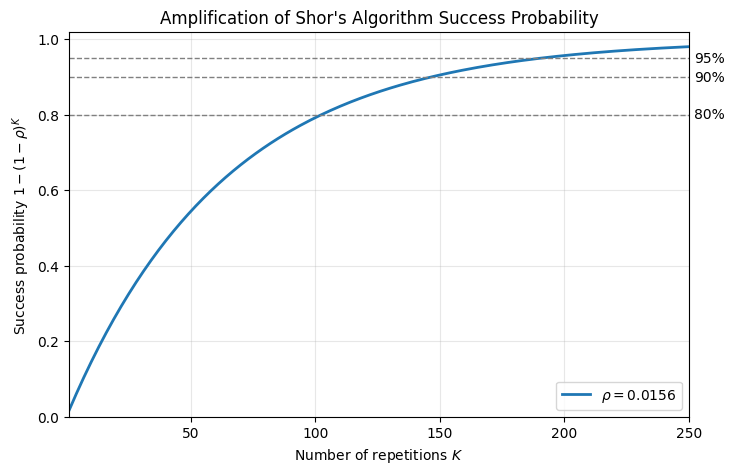

```python
import numpy as np
import matplotlib.pyplot as plt

# One-run success probability from the rough RSA-2048 heuristic estimate
rho = 0.0156

K = np.arange(1, 251)
success_prob = 1 - (1 - rho)**K

plt.figure(figsize=(8, 5))
plt.plot(K, success_prob, linewidth=2, label=rf"$\rho={rho}$")

plt.axhline(0.8, linestyle="--", linewidth=1, color="gray")
plt.axhline(0.9, linestyle="--", linewidth=1, color="gray")
plt.axhline(0.95, linestyle="--", linewidth=1, color="gray")

plt.text(252, 0.8, "80%", va="center", fontsize=10)
plt.text(252, 0.9, "90%", va="center", fontsize=10)
plt.text(252, 0.95, "95%", va="center", fontsize=10)

plt.xlabel("Number of repetitions $K$")
plt.ylabel(r"Success probability $1-(1-\rho)^K$")
plt.title("Amplification of Shor's Algorithm Success Probability")
plt.ylim(0, 1.02)
plt.xlim(1, 250)
plt.grid(alpha=0.3)
plt.legend()
plt.show()
```

The success probability approaches $1$ exponentially fast in the number of independent repetitions $K$, while the failure probability decays exponentially as $(1-\rho)^K$. To see why, use the Taylor expansion

$$ \log(1-\rho) = -\rho-\frac{\rho^2}{2}-\frac{\rho^3}{3}-\cdots = -\sum_{n=1}^{\infty}\frac{\rho^n}{n}. $$

For small $\rho$, this gives the approximation $\log(1-\rho)\approx -\rho$. Therefore,

$$ \begin{aligned} (1-\rho)^K &= e^{\log\left((1-\rho)^K\right)} \\ &= e^{K\log(1-\rho)} \\ &\approx e^{-\rho K}. \end{aligned} $$

Hence, the success probability becomes $1-(1-\rho)^K \approx 1-e^{-\rho K}.$ The probability of success per run may be modest, but it is not exponentially small. Since independent repetitions make the failure probability decay exponentially in the number of repetitions, the overall success probability can be amplified efficiently.

Sharper bounds are known. Bourdon and Williams studied the order-finding part in [*Sharp probability estimates for Shor's order-finding algorithm*](https://arxiv.org/abs/quant-ph/0607148). They prove that, with the input-register size specified in Shor's algorithm, the probability of obtaining a nontrivial divisor of the order from a single run of the order-finding subroutine exceeds $0.7$ whenever $N>2^{11}-1$ and $r\geq 40$. They also establish $0.7736$ as an asymptotic lower bound. These sharper estimates show that the heuristic calculation based on combining the Fourier-sampling estimate, the coprimality factor, and the step-6 success bound is useful for intuition, while better probability estimates are available for the order-finding subroutine.

We have now covered not only how Shor's probabilistic algorithm outputs nontrivial factors of an integer $N$, but also why its probability of success is manageable enough to make the algorithm efficient through repetition.

### Gate Complexity of Shor's Algorithm

As discussed, the classical components of Shor's algorithm can be run efficiently. They rely mainly on standard number-theoretic procedures such as the Euclidean algorithm for computing gcds and the continued-fraction algorithm, both of which run in polynomial time. The main cost of Shor's algorithm comes from the quantum order-finding subroutine. Within this subroutine, the two resource-intensive operations are modular exponentiation and the inverse quantum Fourier transform. Of these, modular exponentiation is the dominant cost. Shor describes modular exponentiation as the "bottleneck" of the quantum factoring algorithm.

For an $n$-bit integer $N$, where $n=\lceil \log_2 N\rceil$, the phase register has size roughly $t\approx 2n$. The inverse QFT on this register has gate complexity $O(t^2)=O(n^2)$ in the standard implementation. On the other hand, quantum modular exponentiation has gate complexity $O(n^3)$ with reversible arithmetic. Thus, the quantum order-finding subroutine is dominated by modular exponentiation, and the overall gate complexity of the textbook version of Shor's algorithm is usually quoted as $O(n^3)$. Although the degree of the polynomial is three, this is still polynomial in the input size $n$, which makes Shor's algorithm a polynomial-time quantum algorithm for integer factorization. This was a major theoretical breakthrough and one of the main reasons Shor's algorithm played such an important role in the development of quantum computing! It increased the interest in the field, alongside earlier motivations such as the natural suitability of quantum computers for simulating quantum mechanical systems and quantum chemistry, as noted by Richard Feynman and other scientists.

### Resource Estimates for Shor's Algorithm

Now that we have discussed Shor's algorithm and its implementational aspects, such as probability of success and gate complexity, we can obtain rough resource estimates for running the algorithm at a cryptographically relevant scale. Let us consider factoring a 2048-bit integer. In the schematic version of the algorithm, this requires roughly $t\approx 4096$ qubits for the phase register and $n=2048$ qubits for the modular exponentiation register, giving $6144$ logical qubits before expanding the modular exponentiation circuit.

However, modular exponentiation itself requires additional reversible arithmetic workspace. A construction by Vedral, Barenco, and Ekert, described in [*Quantum Networks for Elementary Arithmetic Operations*](https://arxiv.org/abs/quant-ph/9511018), estimates the memory needed for this part of Shor's algorithm as $7n+1$ qubits, where $n$ is the number of bits of $N$. In their accounting, $2n$ qubits are used for the exponent register, $n$ qubits store the value $x^a\bmod N$, and $4n+1$ qubits are used as temporary workspace. Thus, for $n=2048$, this gives $7(2048)+1=14337$ logical qubits.

This is still only the logical-qubit count. With quantum error correction, each logical qubit must be encoded into many physical qubits. As a rough reference, a [January 2026 QuEra blog](https://web.archive.org/web/20260217111727/https://www.quera.com/blog-posts/understanding-fault-tolerant-quantum-computing-for-government) post on fault-tolerant quantum computing gives a broad estimate of about $100$ to $1000$ physical qubits per logical qubit.

Taking the upper end of this range, namely $1000$ physical qubits per logical qubit, the Vedral-Barenco-Ekert modular exponentiation estimate corresponds to approximately

$$ 1000\times 14337 \approx 1.4\times 10^7 $$

physical qubits. This places the rough physical-qubit count in the tens-of-millions range!!! To put this into perspective, existing gate-based quantum computers are at the scale of hundreds to low thousands of physical qubits. They are still far from the millions to tens of millions of physical qubits suggested by rough fault-tolerant estimates for cryptographically relevant implementations of Shor's algorithm.

Having estimated the qubit count, we can also look at the gate count. The inverse $\mathrm{QFT}$ on a $t=4096$-qubit phase register uses roughly $\frac{t(t-1)}{2}=\frac{4096\cdot 4095}{2}\approx 8.39\times 10^6$ gates in the standard implementation. By contrast, modular exponentiation scales as $O(n^3)$ with standard reversible arithmetic. For $n=2048$, this gives $2048^3\approx 8.6\times 10^9$ gates.

While these are rough estimates, the sheer scale of the qubit counts and gate counts already points to the engineering challenge involved in realizing Shor's algorithm for cryptographically relevant integers.

That said, the heuristic analysis here provides only very rough estimates. With further optimization, improvements to Shor's algorithm, hardware breakthroughs, especially in quantum error correction, software advancements, and the growing role of artificial intelligence, each part of the stack could bring the theory closer to large-scale practical realization. Even then, such systems would most likely not be broadly commercially available at first. They would more likely appear initially in government settings, specialized laboratories, or large industrial research facilities. As progress continues, access may expand more broadly. In any case, realizing Shor's algorithm at this scale would imply major breakthroughs in quantum computing, and many other applications of quantum computing could become practical as well.

Recent estimates show how much these numbers can change as the arithmetic, error-correction strategy, hardware assumptions, and runtime targets change. In 2021, Gidney and Ekerå's [*How to factor 2048 bit RSA integers in 8 hours using 20 million noisy qubits*](https://quantum-journal.org/papers/q-2021-04-15-433/) gave an optimized fault-tolerant estimate using about 20 million noisy physical qubits. In 2025, Gidney's preprint [*How to factor 2048 bit RSA integers with less than a million noisy qubits*](https://arxiv.org/abs/2505.15917) reduced the physical-qubit count below one million by allowing a longer runtime of "less than a week", showing the tradeoff between qubit count and execution time.

These developments show that resource estimates for Shor's algorithm depend on factors such as the arithmetic implementation, error-correction method, hardware architecture, and runtime target, and can improve as the field develops. A rough dollar valuation for a first RSA-2048-scale fault-tolerant quantum computer could therefore shift with future hardware and software advances, but estimates can still easily reach the multi-billion-dollar range once physical qubits, control systems, cryogenics or other hardware infrastructure, gate execution, error correction, and engineering overhead are included. This makes cryptographically relevant implementations of Shor's algorithm an elusive but scientifically important milestone in the broader development of quantum computing.

### Quantum Factoring Demonstrations

Having reviewed rough resource estimates for applying Shor's algorithm at a cryptographically relevant scale, we can also consider the factoring experiments performed on quantum hardware to date. Numbers such as [551](https://arxiv.org/abs/1611.00998), [56153](https://arxiv.org/abs/1411.6758), and [291311](https://arxiv.org/abs/1706.08061) have been factored using quantum factorization-as-optimization techniques. However, these demonstrations are not based on scalable methods that can crack RSA-type integers in the way Shor's algorithm can. They typically exploit special structure in the chosen integers or reduce the problem to a very small number of binary variables, making the remaining problem straightforward to solve.

Therefore, the relevant question is not simply the largest integer factored using a quantum device, but whether the method used to factor it remains efficient and scalable as the input size grows. Under that stricter interpretation, the landmark experimental demonstration remains the 2001 factorization of $15=3\times 5,$ reported in [*Experimental realization of Shor's quantum factoring algorithm using nuclear magnetic resonance*](https://www.nature.com/articles/414883a).

For a discussion of why apparently nearby cases such as $21$ become much more expensive when the modular multiplications are implemented without using instance-specific shortcuts or prior structural knowledge, see Craig Gidney's 2025 post [*Why haven't quantum computers factored 21 yet?*](https://algassert.com/post/2500). In short, the jump in resources from $15$ to $21$ is large because the modular multiplication subroutines become far more expensive. IonQ published a blueprint in April 2026 detailing a fault-tolerant trapped-ion quantum computing architecture. Notably, the paper provides comprehensive resource estimates for factoring integers of various sizes. For a deeper look, check out the [IonQ blog](https://www.ionq.com/blog/blueprint-for-fault-tolerant-trapped-ion-quantum-computing-the-walking-cat-architecture).

### Classical and Quantum Complexity of Integer Factorization and Its Implications

While Shor's algorithm shows that integer factorization can be solved in polynomial time on a fault-tolerant quantum computer, the best known classical algorithms are subexponential but superpolynomial in the input size. The best known classical method for factoring general large integers is the Number Field Sieve. See the [MathWorld entry on the Number Field Sieve](https://mathworld.wolfram.com/NumberFieldSieve.html) for more information. The importance of Shor's algorithm is that it provides strong evidence for a separation between what quantum computers can do efficiently and what is known to be efficiently achievable classically. However, this seperation is not yet guaranteed and proven. We do not currently know whether integer factorization has a classical polynomial-time algorithm. If such an algorithm were discovered, it would reduce the significance of Shor's algorithm as evidence for quantum advantage in factoring, but it would not eliminate the broader relevance of quantum computing, since other quantum algorithms and applications may still provide advantages.

Integer factorization is viewed as a natural candidate for [$\mathrm{NP}$-intermediate](https://complexityzoo.net/Complexity_Zoo:N#npi). Here, [$\mathrm{NP}$](https://complexityzoo.net/Complexity_Zoo:N#np) is the class of decision problems whose proposed solutions can be verified in polynomial time, and $\mathrm{NP}$-intermediate refers to problems that are in $\mathrm{NP}$ but are neither known to be in [$\mathrm{P}$](https://complexityzoo.net/Complexity_Zoo:P#p) nor known to be [$\mathrm{NP}$-complete](https://complexityzoo.net/Complexity_Zoo:N#npc). The class $\mathrm{P}$ consists of decision problems solvable in polynomial time by a classical computer, while $\mathrm{NP}$-complete problems are the hardest problems in $\mathrm{NP}$ in the sense that every problem in $\mathrm{NP}$ can be efficiently reduced to them. The $\mathrm{NP}$-intermediate status of integer factorization is not proven. Factoring could still turn out to be in $\mathrm{P}$ if a classical polynomial-time algorithm is discovered, and it is also not proven that factoring is not $\mathrm{NP}$-complete.

Shor's algorithm shows that integer factorization is in [$\mathrm{BQP}$](https://complexityzoo.net/Complexity_Zoo:B#bqp), the class of problems solvable by a quantum computer in polynomial time with bounded error. More generally, $\mathrm{P}\subseteq\mathrm{BQP}$, since quantum computers can efficiently simulate classical polynomial-time computation. What remains unknown is whether $\mathrm{P}=\mathrm{BQP}$, and whether any $\mathrm{NP}$-complete problem lies in $\mathrm{BQP}$. The widely held belief is that $\mathrm{NP}$-complete problems are not in $\mathrm{BQP}$.

This gives a more subtle picture: the relationship between $\mathrm{BQP}$ and the classical complexity classes is not fully known. We know that $\mathrm{P}\subseteq\mathrm{BQP}$, but we do not know whether this containment is strict. We also do not know whether $\mathrm{BQP}\subseteq\mathrm{NP}$ or whether $\mathrm{NP}\subseteq\mathrm{BQP}$. What Shor's algorithm shows is that $\mathrm{BQP}$ contains at least one important problem, integer factorization, for which no classical polynomial-time algorithm is known. At the same time, it is widely believed that $\mathrm{NP}$-complete problems are not in $\mathrm{BQP}$.

A related open question is whether quantum computers can solve all natural $\mathrm{NP}$-intermediate candidates efficiently. The answer is not known, and the current evidence suggests that the answer is probably no. Quantum algorithms are especially powerful for problems with exploitable algebraic, such as integer factorization, but other $\mathrm{NP}$-intermediate candidates, such as [graph isomorphism](https://en.wikipedia.org/wiki/Graph_isomorphism), are not known to be in $\mathrm{BQP}$.

Interestingly, in the same paper, Shor also showed that quantum computers can solve the discrete logarithm problem in polynomial time. Like factoring, discrete logarithm is considered a difficult problem in classical cryptography and is another natural candidate for an $\mathrm{NP}$-intermediate problem.

To summarize:

1. Integer factorization and discrete logarithm are in $\mathrm{BQP}$.
2. Integer factorization is a natural candidate for $\mathrm{NP}$-intermediate, but this is not proven.
3. It is conjectured that $\mathrm{P}\neq\mathrm{NP}$. If so, [Ladner's theorem](https://en.wikipedia.org/wiki/NP-intermediate) implies that $\mathrm{NP}$-intermediate problems exist.
4. $\mathrm{P}\subseteq\mathrm{BQP}$.
5. $\mathrm{BQP}$ intersects $\mathrm{NP}$ at least through $\mathrm{P}$, and likely also through problems such as integer factorization.
6. It is widely believed that $\mathrm{NP}$-complete problems are not in $\mathrm{BQP}$.

### Implementation of Shor's Algorithm

We now implement a small case of Shor's algorithm using Qiskit to factor $15=5\times 3$, illustrating how the algorithm can be implemented in practice.

To help with choosing $x \in \mathbb{Z}_{15}^{*}$, let us inspect the useful non-trivial choices among $\mathbb{Z}_{15}^{*}=\{1,2,4,7,8,11,13,14\}$:

| $x$ | $\operatorname{ord}_{15}(x)$ | $x^{\frac{r}{2}}\bmod 15$ |
| --- | --- | --- |
| $2$ | $4$ | $4$ |
| $4$ | $2$ | $4$ |
| $7$ | $4$ | $4$ |
| $8$ | $4$ | $4$ |
| $11$ | $2$ | $11$ |
| $13$ | $4$ | $4$ |

We let $x=2$. Since $\lceil \log_2(15)\rceil=4$, the modular exponentiation register requires $4$ qubits. In Shor's algorithm, we choose $t$ such that $ 15^2 \leq 2^t < 2\cdot 15^2$. The quantum subroutine is used to recover the order of $x$. In practice, we do not know the orders of the elements of $\mathbb{Z}_N^*$ beforehand, since finding such an order is precisely the purpose of the subroutine. The phase-register measurement can correspond to the phase $0$, giving an output $j$ equal to, or close to, $0$. This happens with probability of approximately $\frac{1}{r}$. For cryptographically relevant inputs this is usually negligible. In a real run of Shor's algorithm, such an outcome is treated as a non-successful run and the quantum subroutine is repeated. For this demonstration, we can inspect the output distribution and focus on a representative nonzero outcome when explaining the continued-fraction step.

Since $15^2=225$ and $2^8=256$, we choose $t=8$. Hence, the phase register has $8$ qubits and the modular exponentiation register has $4$ qubits, so the circuit uses $12$ qubits in total.

Now we can initialize a quantum circuit with $12$ qubits, assigning the first $8$ qubits to the phase register and the remaining $4$ qubits to the modular exponentiation register. Following Shor's algorithm, we apply Hadamard gates to the phase register, apply the modular exponentiation unitary, apply the inverse quantum Fourier transform to the phase register, measure the phase register, and then perform the classical post-processing.

In practice, we do not know the order of the chosen element $x\in\mathbb{Z}_N^*$ ahead of time. Therefore, we do not build the modular exponentiation step by looking for where the powers of $x$ repeat. Instead, for each phase qubit $k=0,1,\dots,t-1$, we include a controlled modular multiplication by $x^{2^k}\bmod N$.

Equivalently, the $k$-th phase qubit controls the modular multiplication operator $M_{b_k,N}$, where $b_k=x^{2^k}\bmod N$ and

$$ M_{b_k,N}|y\rangle = |b_k y\bmod N\rangle. $$

For this example, with $x=2$ and $N=15$, these values are

$$ 2^{2^0}\equiv 2,\qquad 2^{2^1}\equiv 4,\qquad 2^{2^2}\equiv 1,\qquad 2^{2^3}\equiv 1,\dots \pmod{15}. $$

Thus, the last six controlled modular multiplications are identity operations. This happens because the order is small in this example. While in this example we could stop the modular exponentiation step after the first two nontrivial controlled multiplications, to remain closer to the structure of Shor's algorithm, we keep the $t=8$ phase register structure and include the controlled modular multiplication step for each phase qubit, with the understanding that the last six are identities in this particular example.

To implement modular exponentiation through controlled modular multiplications, we initialize the modular exponentiation register to the basis state representing $1 \bmod N$. Since the register has $n$ qubits, this state is

$$ |\underbrace{0\cdots 0}_{n-1}1\rangle = |1 \bmod N\rangle. $$

In Qiskit's little-endian convention, this is prepared by applying an $X$ gate to the least significant qubit of the modular exponentiation register. The selected controlled multiplications therefore build

$$ |a\rangle |1\bmod N\rangle \mapsto |a\rangle |x^a\bmod N\rangle. $$

If $a=\sum\limits_{k=0}^{t-1} a_k2^k$, then $x^a=\prod\limits_{k=0}^{t-1}\left(x^{2^k}\right)^{a_k}$.

Therefore, each phase qubit $a_k$ controls whether the modular register is multiplied by $x^{2^k}\bmod N$. Starting from $|1 \bmod N\rangle$, the product of all selected controlled multiplications produces $|x^a\bmod N\rangle$.

Hence, for each phase qubit $k$, we need to build a unitary operator $M_{b_k,N}$, depending on the modulus $N$ and the value $b_k=x^{2^k}\bmod N$, whose action on the modular register is multiplication by $b_k$ modulo $N$.

If the modular register contains a valid residue $y\in\{0,1,\dots,N-1\}$, then we want

$$ M_{b_k,N}|y\rangle = |b_k y\bmod N\rangle. $$

However, $M_{b_k,N}$ acts on an $n$-qubit register, whose Hilbert space has dimension $2^n$. The register can represent the set of integers $\{0,1,\dots,2^n-1\}$, while modular arithmetic modulo $N$ only uses the residue set $\{0,1,\dots,N-1\}$. When $N$ is not a power of two, the extra computational basis states correspond to $\{N,N+1,\dots,2^n-1\}$.

Since quantum operations must be unitary, the action of $M_{b_k,N}$ must be defined reversibly on all $2^n$ basis states. We cannot simply apply $y\mapsto b_k y\bmod N$ to every $0\le y<2^n$, because that would generally make the map many-to-one. For example, reducing all basis states modulo $N$ would send both $|0\rangle$ and $|N\rangle$ to $|0\rangle$.

A straightforward solution is to leave the unused basis states fixed. Thus we define

$$ M_{b_k,N}|y\rangle = \begin{cases} |b_k y\bmod N\rangle, & 0\le y<N,\\ |y\rangle, & N\le y<2^n. \end{cases} $$

This gives a permutation of all $2^n$ computational basis states, and therefore defines a valid unitary operator.

Such a unitary $M_{b_k,N}$ can be constructed as a permutation matrix. In the computational basis, column $y$ represents the input basis state $|y\rangle$, while the row index represents the output basis state. Therefore, if the desired action is

$$ M_{b_k,N}|y\rangle = |\mathrm{target}\rangle, $$

then the matrix entry in row $\mathrm{target}$ and column $y$ is set to $1$.

For a small example, consider $N=3$, $n=2$, and multiplication by $2$ modulo $3$. The two-qubit register can represent $\{0,1,2,3\}$, while arithmetic modulo $3$ uses only $\{0,1,2\}$. We therefore leave the unused state $|3\rangle$ untouched. The desired map is

$$ |0\rangle\mapsto |0\rangle,\qquad |1\rangle\mapsto |2\rangle,\qquad |2\rangle\mapsto |1\rangle,\qquad |3\rangle\mapsto |3\rangle. $$

Thus the corresponding matrix has $1$s in the following $0$-indexed positions,

$$ (0,0),\quad (2,1),\quad (1,2),\quad (3,3), $$

where each ordered pair denotes $(\text{row},\text{column})$. Hence,

$$ M_{2,3} = \begin{pmatrix} 1&0&0&0\\ 0&0&1&0\\ 0&1&0&0\\ 0&0&0&1 \end{pmatrix}. $$

For instance, the column indexed by $1$ is the vector $|2\rangle$, so $M_{2,3}|1\rangle=|2\rangle$.

With that in mind, we can define the modular multiplication operator in Qiskit as follows:

```python
import numpy as np
from math import gcd

from qiskit.circuit.library import UnitaryGate


def modular_multiplication_gate(x_power, N, n):
    """
    Construct the n-qubit modular multiplication gate M_{x_power,N} defined by

        M_{x_power,N} |y> = |x_power * y mod N>,  for 0 <= y < N,
        M_{x_power,N} |y> = |y>,                  for N <= y < 2^n.

    The value x_power should be coprime to N.
    """
    if gcd(x_power, N) != 1:
        raise ValueError("x_power must be coprime to N.")

    dim = 2**n
    unitary = np.zeros((dim, dim), dtype=complex)

    for y in range(dim):
        if y < N:
            target = (x_power * y) % N
        else:
            target = y

        unitary[target, y] = 1

    label = "$M_{" + str(x_power) + "," + str(N) + "}$"
    return UnitaryGate(unitary, label=label)
```

We can verify the small example above by displaying the matrix for $M_{2,3}$, which implements multiplication by $2$ modulo $3$ on a two-qubit register:

```python
from qiskit.visualization import array_to_latex

array_to_latex(modular_multiplication_gate(2, 3, 2))
```

$$ \begin{bmatrix} 1 & 0 & 0 & 0 \\ 0 & 0 & 1 & 0 \\ 0 & 1 & 0 & 0 \\ 0 & 0 & 0 & 1 \\ \end{bmatrix} $$

[This Qiskit tutorial on Shor's algorithm](https://web.archive.org/web/20260517100613/https://quantum.cloud.ibm.com/docs/en/tutorials/shors-algorithm), which also demonstrates factoring $15$ using $x=2$, uses the special structure of this small example to construct the required modular multiplication operators with SWAP gates.

Now we have the required ingredients to implement Shor's algorithm on a simulator. In this implementation, we store the intermediate ideal statevectors after applying the Hadamards, after modular exponentiation, and after the inverse QFT for further inspection and analysis. On actual quantum hardware, direct access to the full statevector is not available. Accessing output statistics requires measurement, which collapses the quantum state and gives samples from the distribution rather than the full statevector.

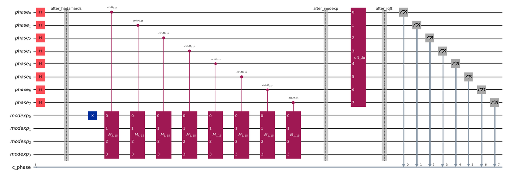

```python
from math import ceil, log2

from qiskit import QuantumCircuit, QuantumRegister, ClassicalRegister
from qiskit.circuit.library import QFTGate
from qiskit_aer import AerSimulator


N = 15
x = 2

n = ceil(log2(N))   # modular exponentiation register size
t = 8              # since 15^2 <= 2^8 < 2*15^2

phase = QuantumRegister(t, "phase")
modexp = QuantumRegister(n, "modexp")
c_phase = ClassicalRegister(t, "c_phase")

qc = QuantumCircuit(phase, modexp, c_phase)

# Create uniform superposition over the phase register
qc.h(phase)
qc.save_statevector(label="after_hadamards")

# Initialize modular exponentiation register to |1 mod N>
qc.x(modexp[0])

# Controlled modular exponentiation
for k in range(t):
    b_k = pow(x, 2**k, N)

    M_bk = modular_multiplication_gate(b_k, N, n).control(1)
    M_bk.label = "$\\mathrm{ctrl}\\text{-}M_{" + str(b_k) + "," + str(N) + "}$"

    qc.append(M_bk, [phase[k]] + list(modexp))

qc.save_statevector(label="after_modexp")

# Apply inverse QFT to phase register
qc.append(QFTGate(t).inverse(), phase)
qc.save_statevector(label="after_iqft")

# Measure phase register
qc.measure(phase, c_phase)

qc.draw("mpl", fold=-1)
```

Before further analysis, we first run the statevector simulation for the three intermediate stages of Shor's circuit. This gives us the statevector data needed to create the plots.

```python
import numpy as np
import matplotlib.pyplot as plt

from qiskit import transpile



# Use the statevector simulator to access the saved intermediate states.
backend_sv = AerSimulator(method="statevector")

# Transpile the circuit for the statevector backend and run it once.
qc_sv_transpiled = transpile(qc, backend_sv, optimization_level=1)
result_sv = backend_sv.run(qc_sv_transpiled).result()

# Extract the saved statevectors from the three stages.
state_after_hadamards = np.asarray(result_sv.data(0)["after_hadamards"])
state_after_modexp = np.asarray(result_sv.data(0)["after_modexp"])
state_after_iqft = np.asarray(result_sv.data(0)["after_iqft"])
```

Then we define helper functions to compute and draw the probabilities. The x-axis values are shown as their corresponding integer values rather than as bit strings.

```python
def phase_register_probabilities(statevector, t):
    phase_probs = np.zeros(2**t)

    phase_mask = 2**t - 1

    for basis_index, amplitude in enumerate(statevector):
        probability = abs(amplitude)**2

        # The full basis index encodes both registers.
        # Since the phase register was added first, Qiskit stores its value
        # in the lowest t bits of the basis index.
        #
        # For example, when t = 8, phase_mask = 255 = 0b11111111,
        # so basis_index & phase_mask keeps only the phase-register bits.
        j = basis_index & phase_mask

        phase_probs[j] += probability

    return phase_probs

def plot_phase_probabilities(probs, title):
    xs = np.arange(len(probs))

    plt.figure(figsize=(14, 4))
    plt.bar(xs, probs, width=0.8)

    plt.xlabel("phase register value $j$")
    plt.ylabel("probability")
    plt.title(title)
    plt.xticks(np.arange(0, len(probs) + 1, 16))
    plt.grid(axis="y", alpha=0.3)
    plt.show()
```

We first compare the phase register probabilities after the Hadamards and after modular exponentiation. As expected, both distributions are uniform. This does not mean that modular exponentiation had no effect. Rather, the effect is not visible in the phase register probabilities alone.

To confirm that the phase register probabilities are unchanged, we also plot the absolute difference between the two distributions.

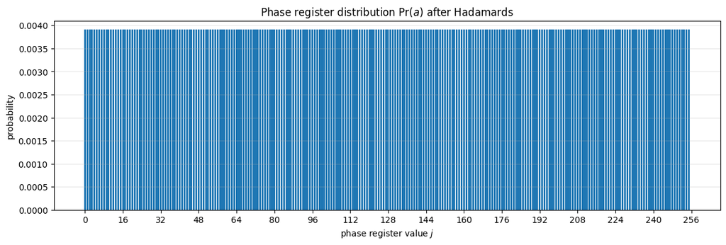

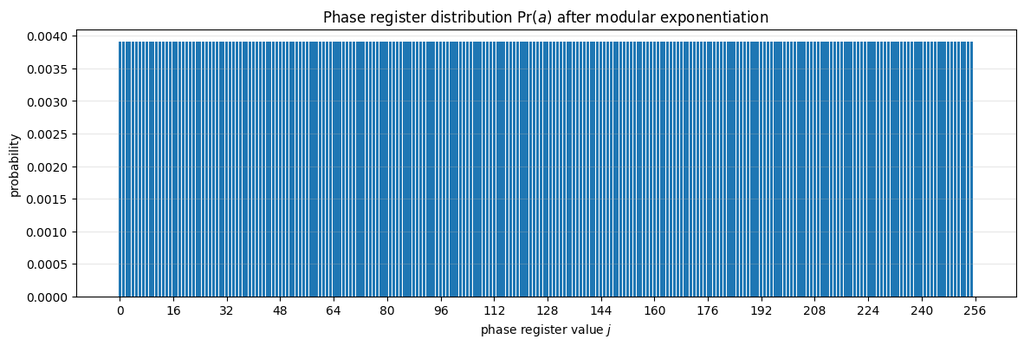

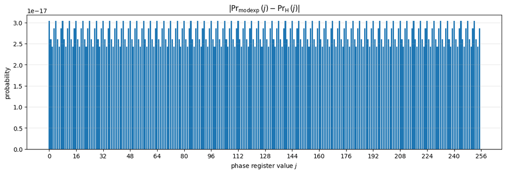

```python
probs_after_hadamards = phase_register_probabilities(state_after_hadamards, t)
probs_after_modexp = phase_register_probabilities(state_after_modexp, t)
absolute_probability_difference = np.abs(probs_after_modexp - probs_after_hadamards)

plot_phase_probabilities(probs_after_hadamards, r"Phase register distribution $\Pr(a)$ after Hadamards")
plot_phase_probabilities(probs_after_modexp, r"Phase register distribution $\Pr(a)$ after modular exponentiation")
plot_phase_probabilities(absolute_probability_difference, r"$|\Pr_{\mathrm{modexp}}(j)-\Pr_{\mathrm{H}}(j)|$")
```

As expected, the distributions after the Hadamards and after modular exponentiation are almost identical. The absolute difference is on the order of $10^{-17}$, which comes from numerical precision and can be treated as $0$.

Let us unpack why these phase register probability distributions are identical, and then explain how the underlying quantum states differ. This will also show what kind of visualization is needed to see the effect of modular exponentiation.

After applying the Hadamards to the phase register, but before modular exponentiation, the state is

$$ |\psi_1\rangle = \sqrt{\frac{1}{2^t}} \sum_{a=0}^{2^t-1} |a\rangle |0\rangle^{\otimes n}. $$

If we only inspect the phase register, every phase register value has probability

$$ \Pr(a)=\frac{1}{2^t}. $$

As part of the modular exponentiation step in this implementation, we first prepare the modular exponentiation register in the state $|1\bmod N\rangle$ and then apply the controlled modular multiplications. After modular exponentiation, the state becomes

$$ |\psi_2\rangle = \sqrt{\frac{1}{2^t}} \sum_{a=0}^{2^t-1} |a\rangle |x^a\bmod N\rangle. $$

Again, if we only inspect the phase register, all phase register values have the same probability,

$$ \Pr(a)=\frac{1}{2^t}. $$

This is why the phase register probability plots before and after modular exponentiation look identical.

However, the full quantum states are different. The phase register probability $\Pr(a)$ only asks how likely it is to observe a given value $a$ in the phase register, without keeping track of the modular exponentiation register. To see the effect of modular exponentiation, we instead look at the joint probability

$$ \Pr(a,y), $$

where $a$ is the phase register value and $y$ is the modular exponentiation register value.

Before modular exponentiation, the modular exponentiation register is fixed at $y=0$. Therefore,

$$ \Pr(a,y) = \begin{cases} \frac{1}{2^t}, & y=0,\\ 0, & y\neq 0. \end{cases} $$

After modular exponentiation, the modular exponentiation register stores the value determined by the phase register, namely $y=x^a\bmod N$. Therefore,

$$ \Pr(a,y) = \begin{cases} \frac{1}{2^t}, & y=x^a\bmod N,\\ 0, & y\neq x^a\bmod N. \end{cases} $$

For $x=2$ and $N=15$, this gives $2^a\bmod 15=1,2,4,8,1,2,4,8,\dots$, which repeats with period $4$. Therefore, the joint probability $\Pr(a,y)$ reveals the periodic correlation created by modular exponentiation, even though the phase register probability $\Pr(a)$ remains uniform.

With this interpretation of $\Pr(a)$ as the phase register distribution and $\Pr(a,y)$ as the joint distribution of the phase register and modular exponentiation register, we now define helper functions to visually inspect how the joint distribution changes after the Hadamards and after modular exponentiation.

```python
def joint_phase_modexp_probabilities(statevector, t, n):
    joint_probs = np.zeros((2**t, 2**n))

    for basis_index, amplitude in enumerate(statevector):
        probability = abs(amplitude)**2

        # Decompose the full basis index as
        # basis_index = phase_value + 2^t * modexp_value.
        # The remainder gives the phase register value, and the quotient gives the
        # modular exponentiation register value.
        phase_value = basis_index % (2**t)
        modexp_value = basis_index // (2**t)

        joint_probs[phase_value, modexp_value] += probability

    return joint_probs

def plot_joint_distribution(joint_probs, title):
    # Remove tiny numerical roundoff values before plotting the nonzero entries.
    cleaned_probs = joint_probs.copy()
    cleaned_probs[np.isclose(cleaned_probs, 0, atol=1e-12)] = 0

    # Find the basis pairs (a, y) with nonzero probability.
    phase_values, modexp_values = np.nonzero(cleaned_probs)

    # Use only the y-values that actually appear in the distribution.
    used_y_values = sorted(set(modexp_values))

    cmap = plt.get_cmap("tab10")
    color_map = {
        y: cmap(index % 10)
        for index, y in enumerate(used_y_values)
    }

    plt.figure(figsize=(14, 4))

    for y in used_y_values:
        mask = modexp_values == y

        plt.scatter(
            phase_values[mask],
            modexp_values[mask],
            s=16,
            color=color_map[y],
            label=f"$y={y}$",
            alpha=0.85
        )

    plt.xlabel("phase register value $a$")
    plt.ylabel("modular exponentiation register value $y$")
    plt.title(title)
    plt.yticks(range(joint_probs.shape[1]))
    plt.grid(alpha=0.25)
    plt.legend(loc="upper right", ncol=min(len(used_y_values), 5), fontsize=9)
    plt.show()
```

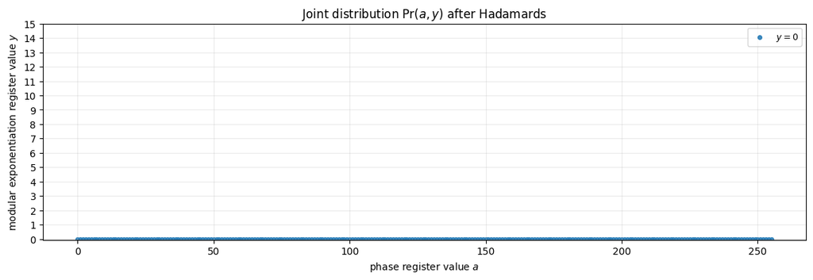

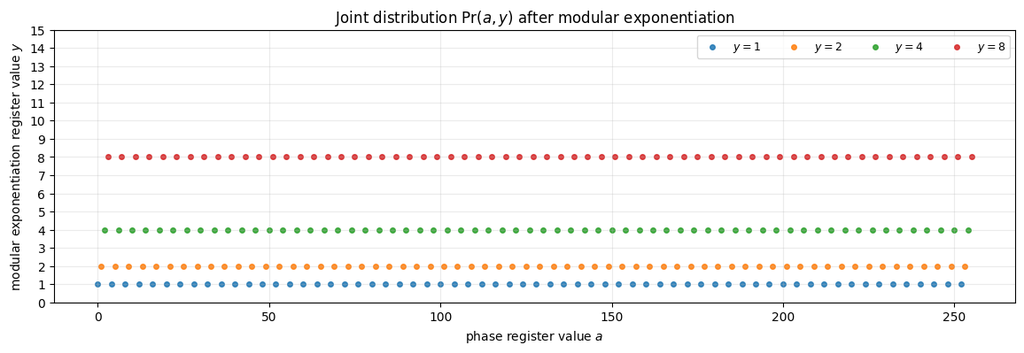

```python
joint_after_hadamards = joint_phase_modexp_probabilities(state_after_hadamards, t, n)
joint_after_modexp = joint_phase_modexp_probabilities(state_after_modexp, t, n)

plot_joint_distribution(joint_after_hadamards,r"Joint distribution $\Pr(a,y)$ after Hadamards")
plot_joint_distribution(joint_after_modexp, r"Joint distribution $\Pr(a,y)$ after modular exponentiation")
```

Based on the earlier probability discussion, the nonzero values of $\Pr(a,y)$ have the same probability in both cases, namely $\frac{1}{2^t}=\frac{1}{256}\approx 0.0039$. After the Hadamards, the modular exponentiation register is still fixed at $y=0$, so the nonzero entries all lie along the same horizontal line. After modular exponentiation, the nonzero entries occur at $y=2^a\bmod 15$, which cycles through $1,2,4,8$ with period $4$. All other values of $y$ have probability $0$ for this choice of $x=2$.

To summarize our observations up to this point, the phase register probability $\Pr(a)$ before the inverse QFT is a marginal distribution, obtained by summing the joint probability $\Pr(a,y)$ over all modular exponentiation values $y$. That is,

$$ \Pr(a)=\sum_{y=0}^{2^n-1}\Pr(a,y). $$

This marginal distribution is uniform both after the Hadamards and after modular exponentiation. However, the joint distributions are different. Modular exponentiation creates correlations. The inverse QFT acts on the phase register before measurement, while these correlations are still present in the joint quantum state. It converts the regular spacing among phase register values with the same modular exponentiation value into peaks in the phase register. Therefore, the measurement statistics after the inverse QFT reflect the periodic correlations created by modular exponentiation.

Now we can plot the phase register distribution after the inverse QFT is applied.

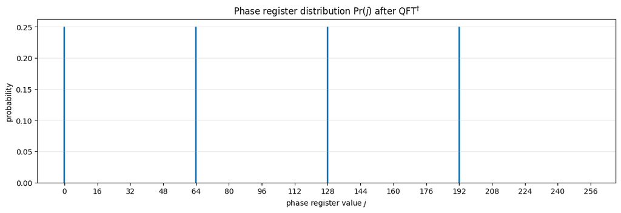

```python
probs_after_iqft = phase_register_probabilities(state_after_iqft, t)

plot_phase_probabilities(probs_after_iqft, r"Phase register distribution $\Pr(j)$ after $\mathrm{QFT}^{\dagger}$")
```

As the plot shows, after applying the inverse QFT, as expected, the distribution has sharp peaks around certain integers. In this case, those peaks occur at $0,64,128,192$. At first glance, it may not be immediately clear why there are four peaks or why they are spaced $64$ apart, but these values contain the information that can lead to recovering the order of $x=2$ in $\mathbb{Z}_{15}^*$, and therefore to factor $15$. In practice, and especially on noisy hardware, the distribution may spread around the expected peak locations. As long as the peaks remain sufficiently distinguishable, the measurement outcomes can still provide enough information to recover the period through the continued fraction step.

The reason there are four peaks is that, before the inverse QFT and after modular exponentiation, the phase register values are grouped according to their remainder modulo $r$:

$$ a=mr+b,\qquad b=0,1,\dots,r-1. $$

There are exactly $r$ possible remainders $b$. For $r=4$, these are $b=0,1,2,3$. Each group collects all phase register values congruent to $b$ modulo $r$:

$$ b,\; b+r,\; b+2r,\;\dots $$

When $r$ divides $2^t$, each group has exactly the same length, and the inverse QFT maps these regularly spaced groups to nonzero amplitudes only at frequencies satisfying

$$ j=s\frac{2^t}{r}, \qquad s=0,1,\dots,r-1. $$

There are exactly $r$ such values because $s$ ranges over $0,\dots,r-1$. With $t=8$ and $r=4$, these values are

$$ \frac{0\cdot 256}{4},\quad \frac{1\cdot 256}{4},\quad \frac{2\cdot 256}{4},\quad \frac{3\cdot 256}{4}, $$

which gives

$$ 0,\;64,\;128,\;192. $$

This explains why there are exactly four peaks, spaced $64$ apart, starting from $0$.

Having discussed the intermediate results of Shor's circuit implementation, we can now perform the measurement. On quantum hardware, we sample measurement outcomes from the phase register, and these samples reveal the four peaks.

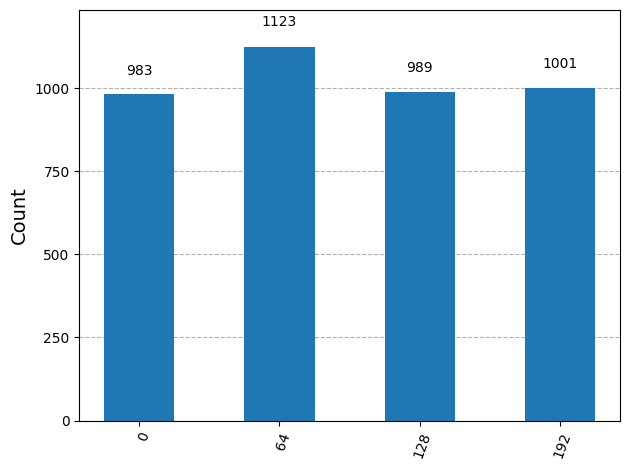

```python
from qiskit.visualization import plot_histogram

# Use the Aer simulator for shot-based measurement sampling.
backend = AerSimulator()

# Transpile the circuit into operations supported by the simulator.
qc_transpiled = transpile(qc, backend=backend, optimization_level=1)

# Run the circuit and collect phase-register measurement outcomes.
result = backend.run(qc_transpiled, shots=4096).result()
counts = result.get_counts()

# Convert measured bitstrings into integer phase-register values j.
integer_counts = {int(bitstring, 2): count for bitstring, count in counts.items()}

plot_histogram(integer_counts)
```

Having collected the measurement samples, we now transition to the classical post-processing step. As discussed earlier, the measurement outcome $j=0$ does not reveal useful information about the period, so we disregard it in the post-processing step.

For the nonzero measurement outcomes, we consider the fractions $\frac{j}{2^t}$. In this example, $t=8$, so $2^t=256$. The relevant nonzero peaks are $j=64,128,192$, which give $\frac{64}{256}=\frac{1}{4}$, $\frac{128}{256}=\frac{1}{2}$, and $\frac{192}{256}=\frac{3}{4}$.

The fractions $\frac{1}{4}$ and $\frac{3}{4}$ reveal the candidate period $r=4$. Indeed, with $x=2$ and $N=15$, we have $2^4=16\equiv 1 \pmod{15}$, so $r=4$ satisfies the period condition in step 5 of the algorithm.

The outcome $\frac{128}{256}=\frac{1}{2}$, is more subtle. It corresponds to $\frac{2}{4}$ before reduction, but continued fractions return reduced fractions, so the denominator becomes $2$ rather than $4$. If we test this candidate, we get $ 2^2=4\not\equiv 1 \pmod{15}$. Therefore $r=2$ does not satisfy the period condition in step 5, and we reject it.

Using the successful candidate $r=4$, we now check the step 6 conditions. The period is even, and $2^{\frac{4}{2}}=2^2=4\not\equiv -1 \pmod{15}$.

Therefore we compute

$$ \gcd\left(2^{\frac{4}{2}}-1,15\right) = \gcd(3,15) = 3, $$

and

$$ \gcd\left(2^{\frac{4}{2}}+1,15\right) = \gcd(5,15) = 5. $$

We verify that $3 \times 5 = 15$.

Therefore, the factors of 15 are 3 and 5 by Shor's algorithm!

For completeness, the continued fraction step can also be implemented efficiently.

```python
from fractions import Fraction

for j in sorted(integer_counts):
    # The outcome j = 0 does not provide useful period information.
    if j == 0:
        continue

    # Use continued fractions to approximate j / 2^t by s / r.
    fraction = Fraction(j, 2**t).limit_denominator(N)
    r_candidate = fraction.denominator

    print(f"j = {j:3d}, j/2^t = {fraction}, candidate r = {r_candidate}")

    # check whether the candidate denominator is a valid period.
    if pow(x, r_candidate, N) != 1:
        print("  rejected: candidate does not satisfy x^r = 1 mod N")
        continue

    # the period must be even.
    if r_candidate % 2 != 0:
        print("  rejected: candidate period is odd")
        continue

    # this case would produce trivial factors.
    x_to_half_period_mod_N = pow(x, r_candidate // 2, N)
    if x_to_half_period_mod_N == N - 1:
        print("  rejected: x^(r/2) = -1 mod N")
        continue

    # Extract the factors using gcd computations.
    factor_1 = gcd(x_to_half_period_mod_N - 1, N)
    factor_2 = gcd(x_to_half_period_mod_N + 1, N)

    if factor_1 not in {1, N} and factor_2 not in {1, N}:
        print(f"  success: factors are {factor_1} and {factor_2}")
    else:
        print("  rejected: only trivial factors found")
```

```
j =  64, j/2^t = 1/4, candidate r = 4
  success: factors are 3 and 5
j = 128, j/2^t = 1/2, candidate r = 2
  rejected: candidate does not satisfy x^r = 1 mod N
j = 192, j/2^t = 3/4, candidate r = 4
  success: factors are 3 and 5
```

As expected, the outcomes corresponding to $\frac{1}{4}$ and $\frac{3}{4}$ recover the candidate period $r=4$, while the outcome corresponding to $\frac{1}{2}$ gives the reduced denominator $2$, which fails the period test $2^r\equiv 1\pmod{15}$. Once $r=4$ is found, the final gcd computations recover the nontrivial factors $3$ and $5$.

Note that in our implementation we used Qiskit's circuit and simulation tools, while constructing the modular multiplication operator as a unitary. For a similar implementation in the PennyLane ecosystem, the tutorials [How to use quantum arithmetic operators](https://pennylane.ai/qml/demos/tutorial_how_to_use_quantum_arithmetic_operators) and [Period finding: A problem at the heart of quantum computing](https://pennylane.ai/qml/demos/tutorial_period_finding) are useful references.

### Conclusion

We have explored one of the most fundamental quantum algorithms, Shor's algorithm. It supports the claim that quantum computers can solve certain problems much more efficiently than any known classical algorithm. In the case of integer factorization, Shor's algorithm provides a superpolynomial speedup over any known classical factoring methods.

As we saw, Shor's algorithm is composed of classical pre-processing, a quantum order finding subroutine, and classical post-processing. The classical parts can be carried out efficiently. The main computational cost comes from the quantum order finding subroutine, especially the modular exponentiation component, which dominates the resource cost and leads to $O(n^3)$ gate complexity estimate. Additionally, Shor's algorithm is probabilistic. A single run may fail to produce nontrivial factors of the input integer, because the measurement outcome may not reveal the period, the continued fraction step may return only a divisor of the period, or the final conditions needed to extract nontrivial factors may fail. However, the success probability can be amplified by repeating the algorithm. As discussed, even modest single-run success probabilities can become useful after repeated runs, and sharper analyses in the literature provide stronger probability estimates for the order finding subroutine. As of May 2026, and as noted in IonQ's 2026 report [*Fault-Tolerant Quantum Computing with Trapped Ions: The Walking Cat Architecture*](https://arxiv.org/pdf/2604.19481), the record-size implementation of Shor's algorithm on a quantum device remains the factorization of $15=3\cdot 5$. At the same time, there is ongoing work on resource estimates and architectures for scaling Shor's algorithm to cryptographically relevant sizes. For example, Gidney's 2025 preprint [*How to factor 2048 bit RSA integers with less than a million noisy qubits*](https://arxiv.org/abs/2505.15917) argues that RSA-2048-scale factoring may be possible with fewer than one million noisy qubits under particular architectural and runtime assumptions. Together, these developments show how progress in theory, algorithms, hardware, and error correction gradually moves Shor's algorithm from a theoretical result toward possible real-world implementation. This movement from theory to application is also why the cryptographic implications of quantum computing are taken seriously today. As quantum computing changed the landscape of what must be considered secure, NIST initiated its [post-quantum cryptography standardization](https://csrc.nist.gov/projects/post-quantum-cryptography/post-quantum-cryptography-standardization/call-for-proposals) effort. More broadly, the same progress is part of a growing quantum computing ecosystem aimed at developing applications beyond cryptography, including quantum simulation, optimization, chemistry, materials science, and other areas where quantum computation may provide new computational tools.

We also implemented a small instance of Shor's algorithm in Qiskit to factor $15$. The simulation showed how the probability distributions evolve through the algorithm. The phase register probabilities after the Hadamards and after modular exponentiation looked identical, but the joint probability distribution revealed that modular exponentiation had created correlations between the phase register and the modular exponentiation register. Applying the inverse QFT transformed those periodic correlations into peaks in the phase register, and the classical continued fraction step used those peaks to recover the period and factor $15$.

In short, Shor's algorithm invites us to view quantum computing as a powerful tool for solving challenging problems, one that may help humanity, under the right conditions, continue its quest to understand the universe.

### Appendix 1: Number Theory Background

**Modular Arithmetic**: We write $a \equiv b \pmod{N}$ if $N$ divides $a - b$, or equivalently, if $a$ and $b$ leave the same remainder when divided by $N$. For example, $17 \equiv 2 \pmod{5}$ because $5$ divides $17 - 2 = 15$.

**GCD and Coprimality:** The greatest common divisor of two integers $a$ and $b$, written $\gcd(a, b)$, is the largest positive integer that divides both $a$ and $b$. Two integers are called coprime if $\gcd(a, b) = 1$, meaning they share no common factor other than 1. For example, $\gcd(14, 15) = 1$, so 14 and 15 are coprime, while $\gcd(12, 15) = 3$, so they are not.

**The Multiplicative Group $\mathbb{Z}_N^*$:** The set $\mathbb{Z}_N^* = \{a \in \mathbb{Z} \mid 1 \leq a < N \text{ and } \gcd(a, N) = 1\}$ forms a group under multiplication modulo $N$. In other words, it consists of all integers from 1 to $N-1$ that are coprime to $N$. For example, $\mathbb{Z}_{15}^* = \{1, 2, 4, 7, 8, 11, 13, 14\}$. Every element in this group has a multiplicative inverse, meaning for each $a \in \mathbb{Z}_N^*$ there exists some $b \in \mathbb{Z}_N^*$ such that $a \cdot b \equiv 1 \pmod{N}$.

**Euler's Totient Function:** Euler's totient function $\varphi(N)$ counts the number of integers from 1 to $N-1$ that are coprime to $N$, so $\varphi(N) = |\mathbb{Z}_N^*|$. For $N = p \times q$ where $p$ and $q$ are distinct primes, this simplifies to $\varphi(N) = (p-1)(q-1)$. By result from number theory, Euler's theorem, we know that $a^{\varphi(N)} \equiv 1 \pmod{N}$ for any $a \in \mathbb{Z}_N^*$. This guarantees that the order of any element divides $\varphi(N)$.

**Order of an Element:** The order of $a \in \mathbb{Z}_N^*$ is the smallest positive integer $r$ such that $a^r \equiv 1 \pmod{N}$. This is the quantity that the quantum part of Shor's algorithm finds. For example, in $\mathbb{Z}_{15}^*$, the order of 7 is 4 because $7^1 \equiv 7$, $7^2 \equiv 4$, $7^3 \equiv 13$, $7^4 \equiv 1 \pmod{15}$.

**Continued Fractions:** A continued fraction expresses a real number as a nested sequence of integer quotients:

$$a_0 + \cfrac{1}{a_1 + \cfrac{1}{a_2 + \cfrac{1}{\ddots}}}$$

For rational numbers, this expansion is always finite and can be computed using the Euclidean algorithm, making it very efficient. Irrational numbers have infinite continued fraction expansions, but since Shor's algorithm only deals with ratios of integers, we always get a finite expansion.

The key objects are the convergents, which are the rational numbers obtained by truncating the continued fraction at each level. In Shor's algorithm, the quantum measurement yields a ratio $j/2^t$ that approximates $s/r$ for some unknown integers $s$ and $r$. We compute the convergents of $j/2^t$ and look for those whose denominator is less than $N$. Each such denominator is a candidate for the order $r$, which we can verify classically by checking whether $x^r \equiv 1 \pmod{N}$.

As a worked example, consider $19/1024$. The continued fraction coefficients are computed by repeatedly taking the integer part and inverting the remainder:

$$\frac{19}{1024}: a_0 = 0, \quad \frac{1024}{19}: a_1 = 53, \quad \frac{19}{17}: a_2 = 1, \quad \frac{17}{2}: a_3 = 8, \quad \frac{2}{1}: a_4 = 2$$

giving the expansion $[0;\; 53, 1, 8, 2]$, which corresponds to

$$0 + \cfrac{1}{53 + \cfrac{1}{1 + \cfrac{1}{8 + \cfrac{1}{2}}}}$$

The convergents are then $0/1,\; 1/53,\; 1/54,\; 9/485,\; 19/1024$. If we were looking for an order $r < N$, we would check each denominator, such as 53, 54, or 485, by computing $x^r \bmod N$ to see if it equals 1.

### Appendix 2: Timeline of the Development of Shor's Algorithm

*What follows is a summary based on several sources, including Peter Shor's 2020 [interview with David Zierler](https://repository.aip.org/node/129496), later adapted by Ryan Dahn in the 2025 Physics Today article [*Peter Shor on the genesis of Shor's algorithm*](https://physicstoday.aip.org/features/peter-shor-on-the-genesis-of-shors-algorithm), Daniel Simon's recollection quoted in an [AWS Quantum Technologies Blog post](https://web.archive.org/web/20260413200009/https://aws.amazon.com/blogs/quantum-computing/simons-algorithm/), and the relevant conference, journal, and arXiv records. To situate the timeline, it is also useful to note the role of the Symposium on Theory of Computing (STOC) and the Symposium on Foundations of Computer Science (FOCS) in theoretical computer science. STOC is organized under the Association for Computing Machinery (ACM), while FOCS is organized under the Institute of Electrical and Electronics Engineers (IEEE). STOC usually takes place in spring or early summer, while FOCS usually takes place in the fall. As Shor recalls, these are considered two major theoretical computer science conferences in the United States.*

Peter Shor became interested in quantum computing after a talk given by Umesh Vazirani at Bell Labs, where Shor was working, in late 1992. The work discussed in that talk was later presented at STOC 1993 under the title [*Quantum Complexity Theory*](https://dl.acm.org/doi/abs/10.1145/167088.167097), in collaboration with Ethan Bernstein. That paper contains what is now known as the Bernstein-Vazirani algorithm. According to Shor, Vazirani's talk led him to think about what quantum computers might be useful for. Shor then looked up the relatively small number of early papers on quantum computing, including work by Feynman, Deutsch, and Jozsa.

In 1994, Shor was on the program committee for STOC 1994, where he encountered a submission by Daniel Simon on what is now known as Simon's algorithm. Simon's submission was not accepted at STOC 1994. Shor explained that Simon's use of periodicity made him think about whether similar quantum ideas could be applied to number-theoretic problems such as discrete logarithms and factoring. Simon's work was later accepted at FOCS 1994 under the title [*On the Power of Quantum Computation*](https://www.computer.org/csdl/proceedings-article/focs/1994/0365701/12OmNzcxZ5z). Shor's preliminary work was accepted at the same conference under the title [*Algorithms for Quantum Computation: Discrete Logarithms and Factoring*](https://www.computer.org/csdl/proceedings-article/focs/1994/0365700/12OmNqNXErh). Both papers later were published in expanded journal form in *SIAM Journal on Computing* in 1997. Simon's paper was published under the same title as [*On the Power of Quantum Computation*](https://epubs.siam.org/doi/10.1137/S0097539796298637), while Shor's paper was published under the revised title [*Polynomial-Time Algorithms for Prime Factorization and Discrete Logarithms on a Quantum Computer*](https://epubs.siam.org/doi/10.1137/S0097539795293172).

The key idea Shor took from Simon's work was that quantum computation could extract useful information from periodic structure in a way that seemed to offer a speedup over classical computation. This mattered because periodicity also appears in important number-theoretic problems. As Shor recalls, he first found a quantum approach to a special case of the discrete logarithm problem. This suggested that the approach might extend beyond the special case. He then extended the idea to the full discrete logarithm problem, and from there to factoring.

A notable difference between the 1994 conference version and the later expanded version concerns how the quantum Fourier transform component is presented. In the 1994 paper, Shor provided a construction for the quantum Fourier transform, but this construction relied on choosing a suitable smooth number $q$ for the quantum Fourier transform step. Here $q$ is not the integer $N$ being factored. It is an auxiliary register size chosen by the algorithm. Thus, the smoothness condition applied to the quantum Fourier transform register size, not to the input integer $N$ itself. For context, a $B$-smooth number is a positive integer whose prime factors are all at most $B$. Shor also argued that such a suitable $q$ could be found efficiently.

Around the same time, Don Coppersmith, a researcher at IBM, was working on a more efficient quantum Fourier transform construction that would later be incorporated into the expanded version of Shor's algorithm.

> In this paper we will deal with *smooth* numbers $q$ which contain no prime power factor that is larger than $(\log q)^c$ for some fixed $c$. It is also possible to do this transformation in polynomial time for all smooth numbers $q$; Coppersmith shows how to do this for $q=2^k$ using what is essentially the fast Fourier transform, and that this substantially reduces the number of operations required to factor.

In the [1996 arXiv version](https://arxiv.org/abs/quant-ph/9508027) of Shor's paper, Coppersmith's contribution is incorporated more directly into the presentation. Shor writes:

> Luckily, Coppersmith has shown that one can define an approximate Fourier transform that ignores these tiny phase factors, but which approximates the Fourier transform closely enough that it can also be used for factoring.

Coppersmith's work appears to have circulated as an IBM Research Report rather than as a standard journal or conference publication. An arXiv version was later published in January 2002 under the title [*An Approximate Fourier Transform Useful in Quantum Factoring*](https://arxiv.org/pdf/quant-ph/0201067), with the report dated June 1994. Its abstract states:

> We define an approximate version of the Fourier transform on $2^L$ elements, which is computationally attractive in a certain setting, and which may find application to the problem of factoring integers with a quantum computer as is currently under investigation by Peter Shor.

Thus, the development seems to have proceeded as follows. Shor had already used a quantum Fourier transform in the 1994 version, while Coppersmith's work provided a more efficient and approximate quantum Fourier transform implementation. This was later integrated more directly into the expanded 1996/1997 presentation of the algorithm.

Furthermore, it is worth mentioning that Simon's submission to STOC 1994, whose program committee included Shor and which ultimately rejected the work, inspired Shor to make use of periodicity in Shor's algorithm, a connection that also led Simon and Shor to consider merging their work into one paper for FOCS 1994, as noted in this [AWS Quantum Technologies Blog post](https://web.archive.org/web/20260413200009/https://aws.amazon.com/blogs/quantum-computing/simons-algorithm/), where Simon recalls:

> We had in fact agreed to merge the papers if only his was accepted, but the committee fortunately agreed to accept them both, giving us each credit for our respective portions of the resulting achievement.

Note that in this blog post, Simon refers to the dates as 1993 instead of 1994, which appears to be a date slip. The available conference records indicate that the relevant conference cycle was 1994. Peter Shor was on the [STOC 1994 program committee](https://web.archive.org/web/20240625084840/https://acm-stoc.org/stoc1994/stoc94program.pdf), not the [STOC 1993 program committee](https://web.archive.org/web/20250428063846/https://acm-stoc.org/stoc1993/stoc93cfp.pdf), and both Simon's and Shor's papers appeared in FOCS 1994.

In short, the development of Shor's algorithm followed a chain of events. Vazirani's Bell Labs talk sparked Shor's interest in quantum computation, Simon's work highlighted the power of extracting information from periodic structure, Shor connected those ideas to discrete logarithms and factoring, and Coppersmith's work helped refine the quantum Fourier transform implementation that appeared in later presentations of the algorithm.

### Appendix 3: Biography

Peter Williston Shor, born in 1959, is an American theoretical computer scientist and applied mathematician, best known for developing Shor's algorithm. The algorithm was a fundamental breakthrough in quantum computing, showing that quantum computers can theoretically solve cryptographically important problems, such as integer factorization and discrete logarithms, more efficiently than any known classical method.

Shor showed early promise in mathematics. He placed third in the 1977 USA Mathematical Olympiad and won a silver medal at the International Mathematical Olympiad. He received his bachelor's degree in mathematics from the California Institute of Technology (Caltech) in 1981, and completed his doctoral degree in applied mathematics at the Massachusetts Institute of Technology (MIT) in 1985 under the supervision of Frank Thomson Leighton. His thesis was titled [*Random Planar Matching and Bin Packing*](https://dspace.mit.edu/entities/publication/58983042-48a8-46c5-8eb1-e34874582b74).

Shor later joined American Telephone and Telegraph (AT&T), where he was a member of the research staff from [1986 to 2003](https://math.mit.edu/directory/profile.html?pid=247). During this period, he developed Shor's algorithm. In 2003, he joined the MIT faculty as a professor. Although Shor is best known for his factoring algorithm, his broader research spans quantum algorithms, quantum error correction, fault-tolerant quantum computation, quantum information theory, quantum communication, quantum cryptography, and classical topics in algorithms and combinatorics.

Shor has received various awards, including the 1998 Nevanlinna Prize, now known as the International Mathematical Union (IMU) Abacus Medal, the 1999 Gödel Prize, the 2017 Dirac Medal of the International Centre for Theoretical Physics, and the 2025 Claude Shannon Award.

### Appendix: References and Suggested Readings

1. Shor, Peter W. (1994). *Algorithms for quantum computation: discrete logarithms and factoring*. Proceedings of the 35th Annual Symposium on Foundations of Computer Science (FOCS 1994), 124-134. DOI: 10.1109/SFCS.1994.365700.
2. Shor, Peter W. (1997). *Polynomial-Time Algorithms for Prime Factorization and Discrete Logarithms on a Quantum Computer*. SIAM Journal on Computing, 26(5), 1484-1509. DOI: 10.1137/S0097539795293172. [[arXiv](https://arxiv.org/abs/quant-ph/9508027)].
3. Simon, Daniel R. (1997). *On the Power of Quantum Computation*. SIAM Journal on Computing, 26(5), 1474-1483. DOI: 10.1137/S0097539796298637. Earlier conference version: Proceedings of the 35th Annual Symposium on Foundations of Computer Science (FOCS 1994), 116-123. DOI: 10.1109/SFCS.1994.365701.
4. Coppersmith, Don (1994). *An Approximate Fourier Transform Useful in Quantum Factoring*. IBM Research Report. [[arXiv](https://arxiv.org/abs/quant-ph/0201067)].
5. Vedral, Vlatko; Barenco, Adriano; and Ekert, Artur (1996). *Quantum Networks for Elementary Arithmetic Operations*. Physical Review A, 54(1), 147-153. DOI: 10.1103/PhysRevA.54.147. [[arXiv](https://arxiv.org/abs/quant-ph/9511018)].
6. Lavor, C.; Manssur, L. R. U.; and Portugal, R. (2003). *Shor's Algorithm for Factoring Large Integers*. [[arXiv](https://arxiv.org/abs/quant-ph/0303175)].
7. Gidney, Craig (2018). *Halving the Cost of Quantum Addition*. Quantum, 2, 74. DOI: 10.22331/q-2018-06-18-74. [[arXiv](https://arxiv.org/abs/1709.06648)].
8. Wang, Siyi; Li, Xiufan; Lee, Wei Jie Bryan; Deb, Suman; Lim, Eugene; and Chattopadhyay, Anupam (2025). *A Comprehensive Study of Quantum Arithmetic Circuits*. Philosophical Transactions of the Royal Society A: Mathematical, Physical and Engineering Sciences, 383(2288), 20230392. DOI: 10.1098/rsta.2023.0392. [[arXiv](https://arxiv.org/abs/2406.03867)].
9. Barzen, Johanna; and Leymann, Frank (2022). *Continued Fractions and Probability Estimations in Shor's Algorithm: A Detailed and Self-Contained Treatise*. AppliedMath, 2(3), 393-432. DOI: 10.3390/appliedmath2030023. [[arXiv](https://arxiv.org/abs/2205.01925)].
10. Bourdon, P. S.; and Williams, H. T. (2007). *Sharp Probability Estimates for Shor's Order-Finding Algorithm*. Quantum Information & Computation, 7(5), 522-550. Available at: https://dl.acm.org/doi/abs/10.5555/2011832.2011839. [[arXiv](https://arxiv.org/abs/quant-ph/0607148)].
11. Hardy, G. H.; and Wright, E. M. (1979). *An Introduction to the Theory of Numbers*, Fifth Edition. Oxford University Press, New York.
12. Hančl, Jaroslav; and Nguyen, Tho Phuoc (2024). *On a Theorem of Legendre on Diophantine Approximation*. [[arXiv](https://arxiv.org/abs/2407.11166)].
13. Vandersypen, Lieven M. K.; Steffen, Matthias; Breyta, Gregory; Yannoni, Costantino S.; Sherwood, Mark H.; and Chuang, Isaac L. (2001). *Experimental Realization of Shor's Quantum Factoring Algorithm Using Nuclear Magnetic Resonance*. Nature, 414, 883-887. DOI: 10.1038/414883a. [[arXiv](https://arxiv.org/abs/quant-ph/0112176)].
14. Gidney, Craig; and Ekerå, Martin (2021). *How to Factor 2048 Bit RSA Integers in 8 Hours Using 20 Million Noisy Qubits*. Quantum, 5, 433. DOI: 10.22331/q-2021-04-15-433. [[arXiv](https://arxiv.org/abs/1905.09749)].
15. Gidney, Craig (2025). *How to Factor 2048 Bit RSA Integers with Less Than a Million Noisy Qubits*. [[arXiv](https://arxiv.org/abs/2505.15917)].
16. Gidney, Craig (2025). *Why Haven't Quantum Computers Factored 21 Yet?* Algorithmic Assertions. Available at: https://algassert.com/post/2500.
17. IBM Quantum (n.d.). *Shor Algorithm*. IBM Quantum Learning. Accessed May 2026. Available at: https://quantum.cloud.ibm.com/learning/en/courses/fundamentals-of-quantum-algorithms/phase-estimation-and-factoring/shor-algorithm.
18. IBM Quantum (n.d.). *Shor's Algorithm*. IBM Quantum Documentation. Accessed May 2026. Available at: https://quantum.cloud.ibm.com/docs/en/tutorials/shors-algorithm.
19. Martinez de Lejarza, Jorge (Gorka); and Alonso, Guillermo (2024). *How to Use Quantum Arithmetic Operators*. PennyLane Demos. Published November 4, 2024. Accessed May 2026. Available at: https://pennylane.ai/qml/demos/tutorial_how_to_use_quantum_arithmetic_operators.
20. Schuld, Maria (2025). *Period Finding: A Problem at the Heart of Quantum Computing*. PennyLane Demos. Published April 16, 2025. Accessed May 2026. Available at: https://pennylane.ai/qml/demos/tutorial_period_finding.